# North East London Integrated Needs Assessment 2026

Author

NEL ICB Intelligence & Insight Team

Published

31 March 2026

# Executive Summary [ DRAFT ]

This Integrated Needs Assessment provides system wide assessment of current and projected healthcare needs of north east London (NEL). It brings together population demographics, health outcomes, service utilisation, and lived experience to identify where need is greatest and inequalities persist. The analysis uses financial year 2024/25 as its baseline and is structured around the NEL population segmentation model to support population health management and healthcare points of access to support equitable resource allocation.

The Integrated Needs Assessment will be used to inform the development of commissioning decisions and to balance resources and interventions to achieve the greatest improvements in health while narrowing inequalities. The following summary outlines the key insights gleaned from the five thematic chapters of the full report.

##### **Theme 1: Population**

The NEL population is diverse, dynamic and youthful in comparison to national norms. In April 2025, there were 2.45 million patients registered with north east London general practices. Newham is the largest borough with 465k registered patients and Barking & Dagenham the smallest at 260k.

North east London has, in the last decade, been the fastest growing ICB in London and the population will continue to grow with Barking & Dagenham forecasted to see the largest increase to their population by 2041. Migration in the city causes population growth but also significant churn placing a burden on primary care.

The population will also change through aging – inner London boroughs currently skew young with peak numbers in the 20–40 age ranges while outer boroughs such as Havering have an older population more closely mirroring the England age profile.

Our healthcare segmentation model, categorising the population based on health status and healthcare needs shows that while 45% of the population are healthy; 27% have risk factors for long-term health issues, 25% have at least one long-term condition and 3% have complex health status and needs from the healthcare system. Analysis shows age and complexity are particular drivers of spend and very pronounced service needs to that of a younger healthy population.

##### **Theme 2: Social, economic and behavioural drivers**

**The wider determinants** – social, economic and environmental drivers shape the fabric of population health in NEL. NEL ranks among the most deprived integrated care systems nationally. Four boroughs (Barking & Dagenham, Newham, Tower Hamlets, Hackney) rank in the top five nationally for income deprivation and they also score poorly across other domains affecting employment, education, housing and crime. Deprivation produces the precondition for ill-health, erects barriers to accessing services and sustains systematic inequalities.

**Behavioural risks** are mixed; smoking prevalence being above the England average whilst admission for alcohol-specific conditions is lower. However, uptake of health protective measures is poor across north east London with screening checks lower than England in six of the seven boroughs and vaccination coverage worse than the England average in every borough.

##### **Theme 3: Health outcomes**

Health outcomes vary markedly within NEL and relative to England.

**Summary health indicators:** Analysis of summary indicators shows life expectancy at birth in NEL is close to the England average but hides Place-level inequalities: Havering, Redbridge and Waltham Forest exceed the national average whereas Barking & Dagenham and Hackney fall below. Summary measures such as life expectancy at age 65 and distressingly high under-75 mortality for cardiovascular (CVD) and respiratory disease expose urgent unmet need in our most deprived communities.

**Clinical priority areas:** A Core20Plus5 lens has been used to assess prevalence and outcome variation across deprivation, ethnicity and place. Across clinical priority areas, a consistent pattern emerges. For cardio-renal metabolic disease, respiratory conditions, cancer and severe mental illness, crude prevalence rates often appear lower in younger, inner city boroughs. However, age standardised rates reveal substantially higher underlying burden in these same areas, particularly among deprived and ethnically diverse populations. This divergence between crude and standardised measures indicates under-diagnosis, late presentation and unmet need. High levels of emergency admissions, premature mortality and preventable deaths confirm that hidden risk is translating into avoidable harm.

##### **Theme 4: Demand, need and experience of services**

Across north east London, patterns of healthcare utilisation consistently show that where services are used most is not always where underlying need is greatest. Crude utilisation rates primarily reflect population age structure but show where operational pressure is greatest, with higher observed use often seen in areas with older populations. However, once age is accounted for, age standardised rates repeatedly reveal a different picture: underlying need is systematically higher in younger, more deprived and more ethnically diverse populations, particularly in inner London boroughs. This distinction is critical, as reliance on crude rates alone risks under recognising inequality and under estimating future demand in places where population age masks earlier onset of illness, greater complexity and higher intensity of need.

These patterns are consistent across services and population groups. People with long term conditions and complex needs account for a disproportionate share of activity across the system, despite representing a minority of the population, and these high need segments are more prevalent and growing more rapidly in deprived communities. Deprivation, ethnicity and place interact strongly: age standardised analyses show clear deprivation gradients across physical and mental health services, while ethnic inequalities mirror these patterns, with younger population structures concealing underlying burden in some minority ethnic groups. At borough level, younger inner London areas frequently appear low use on crude measures but emerge as high need once age is accounted for, while some outer boroughs move closer to or below average after adjustment.

Community insight aligns closely with this analysis, showing that while people value the quality of care, difficulties accessing timely support—particularly in primary care and mental health—are widespread, and are felt most acutely by deprived communities, minority ethnic groups and people with long term conditions, contributing to later presentation and avoidable escalation of need.

##### **Theme 5: Resource allocation spend analysis**

Using a patient level costed data set an initial analysis shows that age and complexity are the most significant drivers of spend across the system. Havering has the highest average spend per capita whilst Tower Hamlets has the lowest. Ethnicity, gender and deprivation also influence the utilisation of services and therefore spend across services. Deprivation correlates with spend residents in the most deprived deciles generate around 12% more cost per person than those in the least deprived. The spend analysis also highlights that 3% of the population account for 50% of the spend attributable to the activity held in the ICB patient level data.

##### **Cross-Cutting Themes**

Several threads are evident through the five themes. Inequality or unwarranted variation across spatial, socioeconomic, ethnicity, age or deprivation drive risk and contribute to differences in incidence, detection and progression of disease, treatment and outcomes. Rapid population change stretches existing infrastructure, especially where growth coincides with deep disadvantage. Preventive engagement may not be targeted effectively to current levels of need and will require concerted investment in early intervention, screening, vaccination and health promotion informed by culturally competent, linguistically accessible approaches.

Data quality and detection gaps compound challenges – many conditions appear under-recorded especially where demographics diverge from the norm – demanding renewed focus on proactive case finding and removal of access barriers.

Finally, partnership and co-production with communities emerge as fundamental: lived experience points the way to clearer pathways, better communication, holistic support and an ethos of early help that can arrest the slide into crisis.

# Introduction

This Integrated Needs Assessment presents a high-level assessment of the current and future healthcare needs of the population of north east London. It is made up of 5 sections that will build a picture of these needs, through which the ICB will be able to prioritise efforts on the most effective strategies for commissioning services to improve health outcomes.

The scope, both in terms of geography and services covered, is necessarily broad and this document provides only a summary of underlying analysis contained within the Data and Evidence pack. The INA and underlying D&E pack will be further developed over 2026 as the INA process is further developed through engagement with system partner to ensure best utility for informing health priorities and commissioning intentions and future ICB Strategy direction.

The INA adopts a ‘chapter’ structure, where each chapter describes the needs around a specific area of health and social care. Selected chapters reflect the needs of the NEL system and are delivered through the framework of the NEL healthcare segmentation model, recognising that needs for healthcare services are different depending upon health status and that services will need to be commissioned to meet the needs of these segments differentially.

**NoteNotes**

- The analysis presented here, unless indicated differently, takes the financial year 2024/25 as its base.
- For each section, further detail is available in the Data and Evidence Pack.

# 1 Our population

[figure not shown]

## A diverse and changing population

In April 2025, there were 2.45 million patients registered to a NEL GP.

Across our boroughs the population size varies with Newham having the largest GP list (~465k) followed by Tower Hamlets (~391k). In contrast, Barking and Dagenham and Havering serve smaller registered populations (~257–300k).

[figure not shown]

GP registered population by NEL Place, 2025

Our population is young relative to England, but this generalisation at NEL level obscures a nuanced picture by Place.

In Havering the age distribution is close to that of England but the graphic shows that our inner London places (City and Hackney, Tower Hamlets, Newham) differ greatly from England with a pronounced spike across the 20–40 age range; as we move out from the City, the distribution changes with this spike becoming less pronounced as slightly greater proportions are seen in the older age groups.

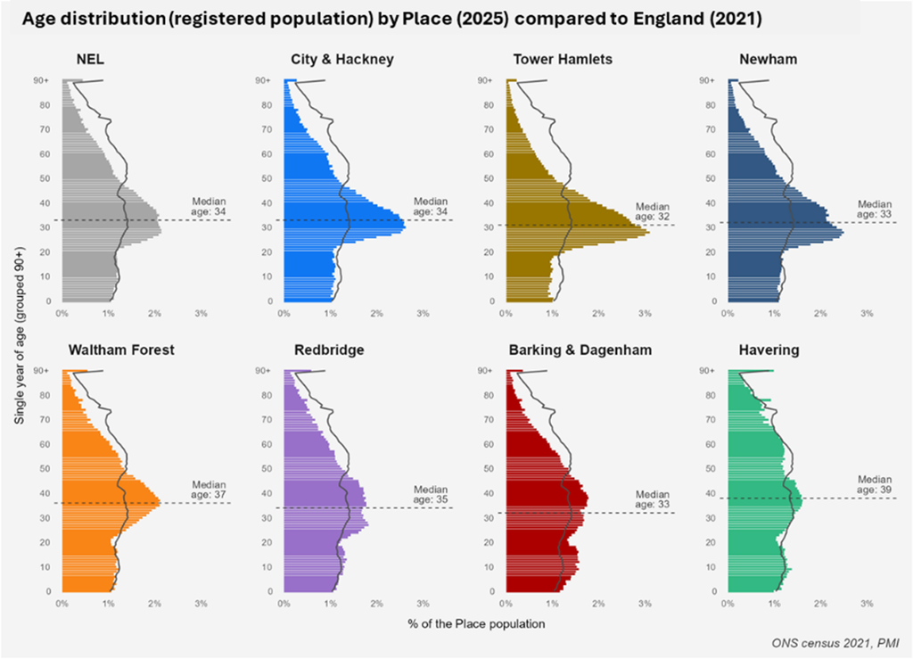

Age distribution by single year of age, April 2025

The population is hugely diverse in terms of ethnicity and language. These factors require consideration when planning services at scale – universal offers may not be suited to all parts of the population.

At NEL level, nearly one third (31%) of the population are of an Asian ethnic group, around 13% of a black ethnic group and 41% of a white ethnic group including white British and “Any other white background”.

In our different boroughs, these percentages vary greatly.1 In Havering, nearly 70% of the population are of a white ethnic background. In contrast, in Redbridge, Newham and Tower Hamlets, groups of Asian ethnic background are a majority over any other major group.

[figure not shown]

Percentage of the NEL GP registered population by ethnic group, March 2025

Census 2021 identified almost 100 different main languages spoken in NEL; the most commonly spoken other than English are Bengali, Urdu, Romanian, Sylheti and Punjabi and this is changing compared to Census 2011. Again, this varies significantly by borough with every area having its own unique diversity. Of NEL places, Newham has the highest proportion of residents with a main language other than English (35%); Havering has the smallest proportion (10%).

[figure not shown]

Top 10 Non-English spoken languages by % of population, March 2025

These cultural and language differences influence health service use and outcomes and this can be further exacerbated where they interact with socioeconomic factors. These differences will influence health service use and outcomes.

### Population change: how it affects services

The population is constantly changing through not just aging but also the effects of migration. North east London has the fastest growing population in London and one of the fastest in the country.

Over the last ten years from 2015 to 2025, the population has grown from c.1.95 million to the 2.45 million in 2025. That growth is forecast to continue and, by 2035, bring an additional 170,000 people to using NEL commissioned healthcare. The growth, through net migration and new births, impacts where our population is based and also the demographic characteristics of the population.

[figure not shown]

Historic and forecast population growth, 2015-2035

**List size change by Place**

For all boroughs, population growth in the 10 years to 2025 has been considerable, in percentage terms ranging from 16% to 38%. These changes are being felt most keenly in Newham, where the 10 years to 2025 have produced growth of nearly 40%.

Over the next 10 years to 2035, Newham will continue to grow a further 15%. Other boroughs where there has been sustained growth in the ten years to, and forecast to be sustained into the next ten years, are Tower Hamlets and Barking & Dagenham.

**Growth by Place last 10 years**

[figure not shown]

**Forecast growth by Place next 10 years**

[figure not shown]

Redbridge, Waltham Forest and Havering experienced growth in the 10 years to 2025 but this has slowed and is forecast to be marginal over the next 10 years. City & Hackney, though experiencing population growth of 23% to 2025, is forecast to see little change going forward. Regardless, for all boroughs the picture of growth over the past 10 years has meant all services are under pressure.

**List size change by age**

Population change is also uneven across age groups, again resulting in more acute pressure being felt on some services than others.

**Historic growth by age last 10 years**

[figure not shown]

In the 10 years from 2015 to 2025, greatest growth was in the 30 to 50 years age groups with an additional 220,000 people in this age group; growth was also considerable in the 10 to 30 years age group (+140,000) and 50–70 years age group (+113,000).

**Forecast growth by age next 10 years**

[figure not shown]

In the next ten years to 2035, the NEL population is forecast to grow by a further 167,000 people. This comprises significant growth of nearly 130,000 people in the 50 + age group - this group often having greater morbidity and corresponding need for healthcare. There is growth of 80,000 people in the 20-50 years group but the total growth is offset by a reduction in all the CYP age-bands 0-20 years that will see the population in these age groups shrink by nearly 30,000 people.

**Population growth in different age groups will affect use of healthcare**

The fact that the age structure of our population is changing will differentially impact the growth of our healthcare segments. While all segments will see some growth, the complex needs segment is growing at triple the rate of the healthy and LTC segments. This equates to over 50% more patients in our most high cost segment (an additional 26k patients).

NEL’s most deprived population are being diagnosed with complex needs at a faster rate than the least deprived. In 2018, 2.1% of NEL’s population had complex needs compared to 3.2% in 2025.

**Migration impacts growth but population churn is a further factor**

Net population change is one factor in generating population growth, but migration impacts the population in other ways by feeding the effect of turnover of around one fifth of the population in any year.

In the most recent FY 24/25, over 1 in 5 patients (20.6%) either joined or left the GP practice, showing substantial mobility within or into the system. While this resulted in a net increase of ~47,000 patients, nearly 230,000 individuals left during the year, with 9.5% of the registered population churning out of NEL entirely.

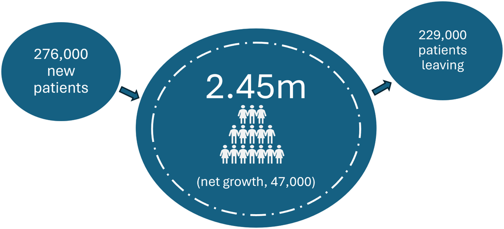

Net population turnover, 2024-25

Summed, this inward and outward migration, or turnover, in itself affects the way services are delivered, especially within primary care where new registrations and de-registrations are administrative work but also result in moving targets for population health improvement.

[figure not shown]

Place population churn, 2024-25

The turnover rate is defined as the proportion of patients moving in and out (new + left) compared to the total current list size. All places are currently growing because new patient acquisition exceeds churn everywhere. However, the balance between the two varies.

Newham and Tower Hamlets show high acquisition but also high churn, indicating high turnover and less stable retention. Havering and City & Hackney have lower churn with solid acquisition, suggesting more stable and sustainable growth. Redbridge and Waltham Forest have only a small gap between patients joining and leaving, meaning growth is modest and could easily reverse if churn rises. Barking & Dagenham stands out with the strongest net growth due to the highest acquisition rate.

## Health status through segmentation

The NEL Segmentation model for healthcare gives us a further way to group our population. This model was developed after widespread system engagement and launched in 2025.

[figure not shown]

NEL ICB ‘core’ population segmentation model

The model was designed to group the population into segments based on people’s health status and their profile of need from healthcare. This means that, within a segment, people will have broadly similar profiles of healthcare use and overall health status even if they have different health conditions, but the profiles of healthcare use (or need) between segments are likely to be markedly different. The model version presented here is our ‘core’ whole population segmentation model; further stratification of any of these segments is available.

45% of the NEL all-age population are within the healthy segment, that is they have no long-term conditions diagnosed or major use of healthcare. 27% are in the risk factors segment where health records of this group indicate one or more risk factors present. This segment are a key target for primary and secondary prevention efforts and will have low use of healthcare services. Risk factors in this context include: obesity, hypertension[^1], smoking or a common mental health disorder.

25% are in the long-term conditions segment and 3% in the complex needs segment.

[figure not shown]

Distribution of the population across the ‘core’ segmentation model

The population pyramid shows how, at different age groups, health status and profile of use of healthcare is different. In very young children, the population is almost exclusively healthy. As we move through childhood, adolescence and young adulthood, we start to see the presence of risk factors and long-term conditions in a small number at each age-band with these two segments becoming increasingly large as the population ages. With exception of tiny numbers, people are not entering the complex needs segment – in total making up just 3% of the population – until at least 40, when the number grows very slowly until, from 80 plus, the population is primarily split between the long-term conditions or complex needs segment.

[figure not shown]

Age structure of the ‘core’ segmentation model

### Population by healthcare segment: Place level

At Place level there is some variation in the proportion of patients in each super-segment but the population counts by Place further influence the volume of services that will be needed to meet the needs of a population at Place.

In the complex needs segment the count of people ranges from 6,475 people (B&D) to c.13,460 people in City & Hackney. This segment have the greatest need for healthcare services across our providers.

Havering has the smallest proportion of people (42%) in the healthy segment and, along with Barking and Dagenham, the count at close to 120,000 people. Tower Hamlets has the largest proportion (49%) in this segment, equating to 192,000 people, but Newham’s larger population means they have a greater number in this segment: 221,000.

**Barking & Dagenham**

[figure not shown]

Source: NEL ICB population metrics

**City & Hackney**

[figure not shown]

Source: NEL ICB population metrics

**Havering**

[figure not shown]

Source: NEL ICB population metrics

**Newham**

[figure not shown]

Source: NEL ICB population metrics

**Redbridge**

[figure not shown]

Source: NEL ICB population metrics

**Tower Hamlets**

[figure not shown]

Source: NEL ICB population metrics

**Waltham Forest**

[figure not shown]

Source: NEL ICB population metrics

# 2 Factors impacting health

## Social, economic and environmental drivers of risk

The wider determinants of health—the social, economic, and environmental conditions in which people live—fundamentally shape population health. They create the preconditions for disease, erect barriers to accessing services, and drive systematic inequalities in healthcare use and outcomes. This unequal distribution of determinants results in widening health disparities across the population.

The English Indices of Deprivation are an important tool for measuring deprivation and were updated in 2025. Deprivation is measured at small area (Lower Super Output Area[^2]) level and can be aggregated; it is presented here at both ICB and local authority level. At ICB footprint level, NEL’s high average rank confirms that deprivation is consistently and widely experienced across the ICB. This is further evidenced by the significant proportion of its Lower-layer Super Output Areas (LSOAs) ranked within the most deprived 10% nationally.

| Overall deprivation index and sub-domains | Average national rank of NEL LSOAs (of 33,755 in total, higher is more deprived) | NEL rank out of 42 ICBs for average LSOA rank (1 = most deprived) | Proportion of LSOAs in most deprived 10% nationally | NEL rank out of 42 ICBs for proportion of LSOAs in most deprived 10% (1 = most deprived) |
| --- | --- | --- | --- | --- |
| **Index of Multiple Deprivation** | **21,548** | **3** | **5.8%** | **20** |
| Income | 23,847 | 1 | 17.7% | 7 |
| Employment | 19,447 | 7 | 1.5% | 38 |
| Education, Skills and Training | 16,946 | 26 | 0.4% | 39 |
| Health Deprivation and Disability | 17,529 | 13 | 2.0% | 29 |
| Crime | 19,920 | 7 | 4.5% | 31 |
| Barriers to Housing and Services | 24,685 | 2 | 24.9% | 5 |
| Living Environment | 23,291 | 4 | 9.7% | 20 |
| *Income Deprivation Affecting Children Index (IDACI)* | *24,516* | *2* | *23.7%* | *3* |
| *Income Deprivation Affecting Older People Index (IDAOPI)* | *23,373* | *1* | *39.0%* | *1* |

Furthermore, NEL is among the most deprived ICBs in England on key measures, ranking poorly in the separate domains that together make up the multiple measure:

- Income Deprivation and Barriers to Housing and Services (most and second most deprived in England)
- Income Deprivation Affecting Older People Index (IDAOPI) – the most deprived in England
- Income Deprivation Affecting Children Index (IDACI) – second most deprived in England
- Crime and Living Environment (within the top 10 nationally)

These structural factors translate directly to population health need. The NHS Core20PLUS5 framework explicitly links adverse determinants like these to unmet health needs, focusing on the most deprived 20% and inclusion health groups. Similarly, the NHS RightCare programme underscores that a significant proportion of variation in healthcare utilisation is driven by underlying population need. Therefore, failing to account for deprivation risks misinterpreting need-based variation as unwarranted clinical practice, rather than a system responding to a population with higher baseline burdens.

The following diagram positions each NEL local authority within the national context using its average deprivation rank, highlighting both intra-regional disparities and acute concentrations of disadvantage.

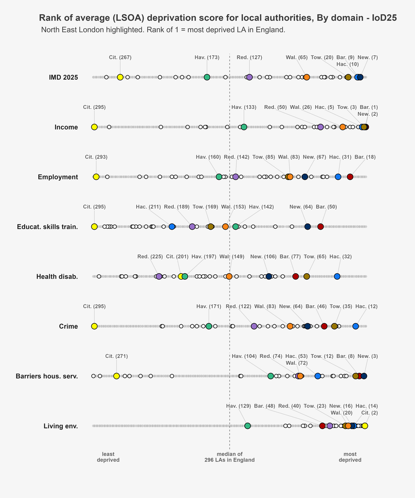

Index of multiple deprivation domains 2025

While the City of London and Havering fall below the England median (i.e., less deprived) on the deprivation index, NEL as a whole is marked by profound socioeconomic challenges. Newham stands out as the most deprived borough in NEL (7th nationally), reflecting widespread and persistent disadvantage across all domains.

The concentration of deprivation is particularly severe. Four NEL boroughs — **Barking and Dagenham (1st), Newham (2nd), Tower Hamlets (3rd), and Hackney (5th)** — are in the top five nationally for income deprivation. This high level of disadvantage is consistent across other key domains:

- **Hackney**: Most deprived in NEL for Health Deprivation & Disability and Crime.
- **Barking and Dagenham**: Most deprived in NEL for Employment and Education.
- **Newham, Barking and Dagenham, and Tower Hamlets**: Among the most deprived nationally for Barriers to Housing and Services.

## Health behaviours

Health seeking and health-protective behaviours (like screening uptake, immunisation, and preventive checks) are powerful levers for reducing preventable illness. Furthermore, some behaviours such as smoking or heavy use of alcohol are known to cause ill-health.

The table shows that behavioural risks and engagement in health protective services vary across north east London with uptake of many protective behaviours such as vaccinations and screening being low, and ‘worse than’ England average in almost all NEL places.

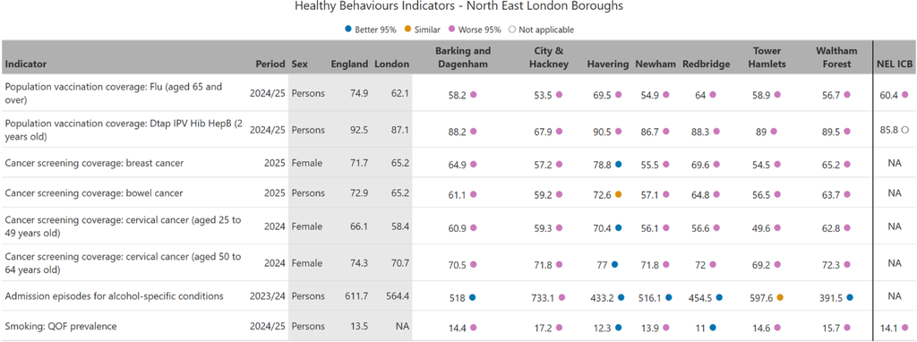

Healthy behaviour indicators

Preventative healthcare measures present a uniform challenge across the region. Lower cancer screening coverage is reported in seven of the eight boroughs — Barking and Dagenham, City of London, Hackney, Newham, Redbridge, Tower Hamlets, and Waltham Forest — with breast, cervical, and bowel cancer screening consistently cited as areas requiring improvement. Low vaccination coverage emerges as the sole universal theme, with every borough for which data is reported performing worse than the England average. This represents a critical region-wide priority for public health intervention.

Beneath the variation we see at Place level, there is evidence of further variation and inequalities in outcomes in groups of different ethnic background and by deprivation.

# 3 Health outcomes

## Summary health indicators

‘Life expectancy (at birth)’ is used as a summary indicator of a population’s health because it captures the cumulative impact of all-cause mortality across the entire life course. It reflects the social, economic and environmental conditions in which people live, as well as the performance and accessibility of health and care services. At system (NEL) level, life expectancy at birth for males and females, is comparably ‘better’ than the England average, but comparably to London neighbours, NEL has the lowest life expectancy at birth.

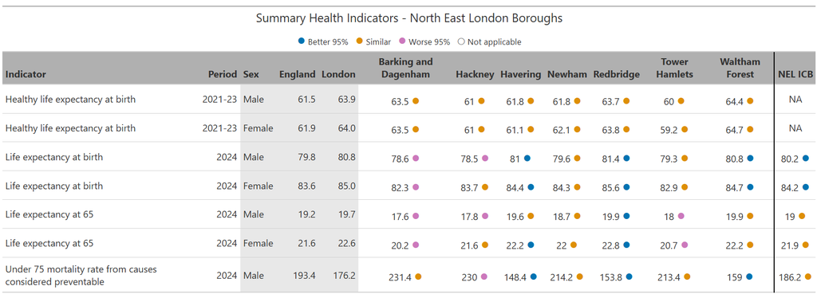

Summary health indicators

The NEL level picture hides inequalities at Place level where there is a more mixed picture with Havering, Redbridge and Waltham Forest having a life expectancy that is ‘better than’ the England average, Newham and Tower Hamlets being ‘similar’, but Barking & Dagenham and Hackney both have rates that are ‘worse than’ the England average. These outcomes in our inner London boroughs signal widespread unmet need in these communities reinforce the need for prioritising prevention, early intervention, and targeted outreach in communities with highest risk and lowest baseline health.

The partner measure of “Life expectancy at age 65” provides insights into health outcomes specifically in older age. It is less influenced by early life mortality and more sensitive to patterns of long term conditions, frailty, and access to effective long term care. We can use this indicator when planning services for ageing populations, assessing pressures on community, primary and social care services, and understanding inequalities in healthy ageing. Across NEL boroughs for life expectancy at age 65, Barking & Dagenham and City & Hackney again have rates that are “worse than” England, but so too does Tower Hamlets. Redbridge has a rate that is “better than” the England average.

## Public health outcomes framework (PHOF)

NEL ICB is in the process of developing and agreeing a system specific outcomes framework to report on indicators that measure and track progress towards improvements in health and reductions in inequalities. The indicators selected will include some from the well-established Public Health Outcomes Framework (PHOF) – itself designed to focus on action to increase healthy life expectancy and reduce differences in life expectancy and healthy life expectancy between communities.

By monitoring outcomes across these indicators the ICB is able to understand trends, benchmark performance, and identify priorities for improving and protecting population health.

The tabs below present, for each NEL borough, an image of a plot of the PHOF outcomes from EDITH PHOF Explorer tool (produced by London Borough of Tower Hamlets Public Health Intelligence team).

The values represented by red dots in the highlighted quadrant bottom left are those indicators where the local value was both ‘worse than’ England and the trend was ‘getting worse. These are the indicators where mitigation or immediate improvement is most urgent.

**Barking & Dagenham**

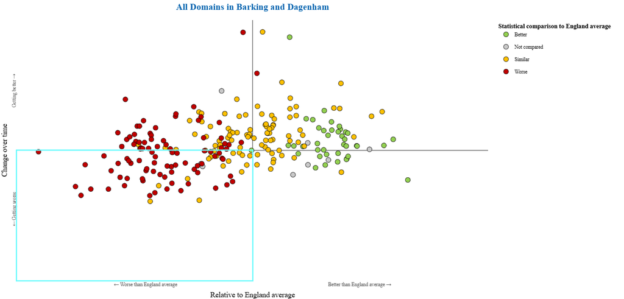

**Hackney**

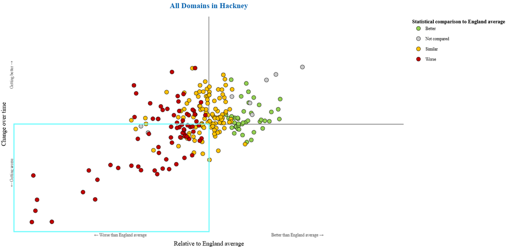

**Havering**

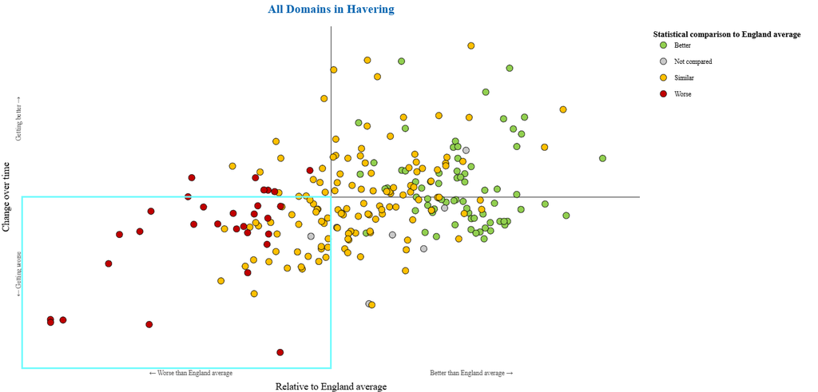

**Newham**

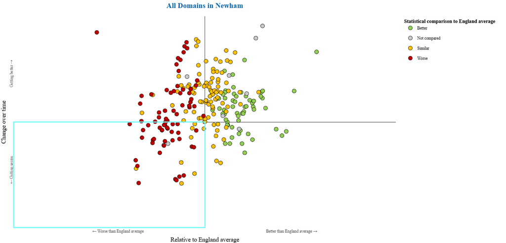

**Redbridge**

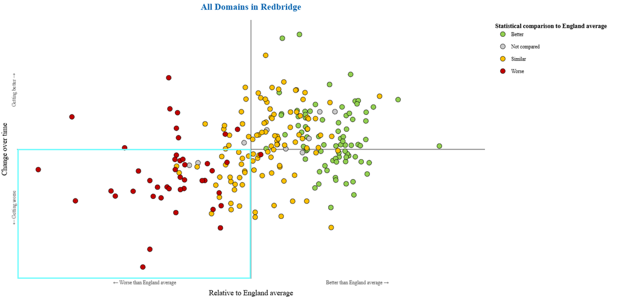

**Tower Hamlets**

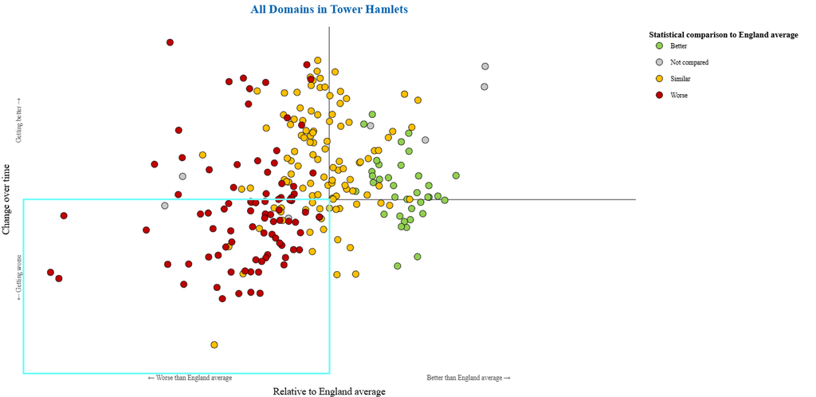

**Waltham Forest**

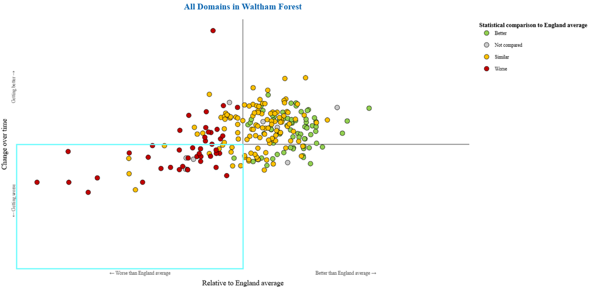

Source: Fingertips PHOF indicators, 2026. Data taken from [EDITH PHOF Explorer for NEL](https://lbthedith.shinyapps.io/phof-explorer-for-nel/) — produced by LB Tower Hamlets.

### PHOF indicators ‘worse than England and getting worse’

The table below summarises those [Public Health Outcomes Framework](https://fingertips.phe.org.uk/profile/public-health-outcomes-framework) indicators where, by Place, the most recent local value was ‘worse than’ England and the trend was ‘getting worse’. These are the indicators where mitigation or immediate action is most urgent.

[output not shown]

## Outcomes across clinical priority areas

The [Core20Plus5 framework](https://www.england.nhs.uk/about/equality/equality-hub/national-healthcare-inequalities-improvement-programme/core20plus5/) lists five areas of clinical priority where accelerated action is required to reduce known healthcare inequalities seen across England. We present the outcomes and inequalities for NEL population under each of these clinical priority areas, with each section comprising relevant indicators drawn from:

- the national Public Health Outcomes Framework and other profiles presented on [Fingertips](https://fingertips.phe.org.uk/) – considering variation at Place level
- NEL Population Metrics (prevalence data) allowing further dis-aggregation by population characteristic as well as Place to identify unwarranted variation in outcomes across population groups and across geographies

### Cardiovascular renal metabolic cluster

The cardio-renal metabolic cluster of conditions including diabetes, hypertension, obesity and cardiovascular disease are a priority for north east London as major drivers of multimorbidity contributing to chronic kidney diseases, rising service demand and pressure across pathways and poor outcomes for our population.

#### Cardio-renal metabolic indicators from the Public Health Outcomes Framework

[figure not shown]

PHOF cardio-renal metabolic indicators

**Chronic kidney disease (CKD): QOF prevalence (2024/25)** The prevalence rate across England is 4.6%. NEL ranges from 2.5% (Hackney) and 2.7% (Tower Hamlets) to 5.0% (Havering) and 4.8% (Waltham Forest). Lower prevalence in inner London will be influenced by younger age structure but there may also be potential variation in detection/coding. Higher CKD prevalence in Havering and Waltham Forest exposes a greater demand for renal risk management and cardiovascular prevention.

**Diabetes: QOF prevalence (2024/25)** England diabetes prevalence is 7.9%. Rates in Barking & Dagenham (10.7%), Redbridge (10.2%), Newham (9.1%) and Havering (9.1%) are significantly higher than the England rate. Rates in Hackney (6.0%), Tower Hamlets (7.2%) and Waltham Fores (7.5%) are lower. Higher diabetes prevalence aligns with the areas also showing higher cardiovascular and diabetes related mortality in this table, suggesting these areas as targets for intensified prevention, treatment optimisation and complication management.

**Hypertension: QOF prevalence (2024/25)** England hypertension prevalence is 15.2%, while all NEL boroughs are lower (7.7–14.7%). Lowest is Tower Hamlets (7.7%) and Hackney (9.2%); highest is Havering (14.7%). Lower QOF prevalence in inner London boroughs is likely partly related to younger population structure, but the contrast with high hypertensive disease mortality in some boroughs suggests that detection, control and treatment optimisation remain critical.

**Estimated prevalence of undiagnosed adult hypertension (2021)** England’s estimated prevalence is 8.6%. NEL values are lower in all boroughs except Havering (8.6%). This may reflect that detection is adequate and/or NEL’s younger age structure but, given the population’s risk profile (including ethnicity and deprivation), higher rates might be expected; variation could therefore also indicate differences in detection or recording.

**Mortality indicators (grouped)** Premature outcomes are highest in Barking & Dagenham (under 75 CVD mortality 146.8; preventable under 75 46.4; under 75 heart disease/stroke 100.7, vs England 100.0, 30.2, 65.8). Newham has the highest diabetes involving (226.3) and hypertensive disease mortality (261.7) (England 109.6, 122.1). Tower Hamlets has the highest all age CVD mortality (272.0 vs England 219.1) and high diabetes/hypertensive mortality (219.4/221.3). Under 75 mortality is considered premature and often avoidable. These indicators reveal that deaths occurring earlier than expected, often reflecting unmet need (late diagnosis, sub optimal control, barriers to care) and inequality (higher exposure to risk factors and lower benefit from prevention and timely treatment).

**Cross-indicator signals:**

- High diabetes prevalence and high premature CVD mortality coincide most clearly in Barking & Dagenham (diabetes 10.7%; under 75 CVD mortality 146.8; preventable 46.4).
- Very high diabetes and hypertension involving mortality in Newham (diabetes mortality 226.3; hypertensive mortality 261.7) indicates a strong need for integrated cardiometabolic prevention and optimisation.
- Tower Hamlets combines low recorded hypertension prevalence (7.7%) with the highest all age CVD mortality (272.0), suggesting the importance of detection, control and wider determinant.

#### Cardio-renal metabolic from the NEL ICB Population Metrics dataset

### Chronic Kidney Disease

Chronic kidney disease (CKD) burden is highest in Black populations, who have by far the highest rates on crude measures and age-standardised rate. The notable shift in rates from crude to age-standardised shows how crude masks an inequality in groups where age profiles are younger (Asian, Mixed).

Deprivation analysis reveals an interesting pattern where crude (observed) rates show higher diagnosis in least deprived quintile, after applying age-standardisation this pattern inverts and a steep deprivation gradient is revealed with the most deprived areas having highest standardised rates. This would also lend strength to hypothesis of systemic under-recording in more deprived communities.

Newham, Tower Hamlets, and Waltham Forest show the greatest underlying risk with the highest age-standardised rates. The translation from low crude rate to high age-standardised rates, such as in Tower Hamlets and Newham, might suggest fewer opportunities for early detection of CKD and under-diagnosis.

**Ethnicity (crude rate)**

[figure not shown]

Source: NEL ICB population metrics

**Ethnicity (age standardised)**

[figure not shown]

Source: NEL ICB population metrics

**Deprivation (crude rate)**

[figure not shown]

Source: NEL ICB population metrics

**Deprivation (age standardised)**

[figure not shown]

Source: NEL ICB population metrics

**Place (crude rate)**

[figure not shown]

Source: NEL ICB population metrics

**Place (age standardised)**

[figure not shown]

Source: NEL ICB population metrics

### Hypertension

Hypertension crude rates are highest in Black then White populations. Asian, Mixed and Other groups are lower than the NEL average. All groups rise substantially after accounting for age; highest rates remain in the Black population but Asian, Mixed and Other increase substantially showing crude rates underestimate need in Asian and Mixed groups because their populations are younger.

Crude rates appear highest in the least deprived quintile, with minor variation elsewhere. Age standardised rates show a clearer gradient, with higher hypertension prevalence in more deprived groups and lower rates in the least deprived, suggesting underlying inequality that crude rates do not capture.

Crude rates are highest in Havering and lowest in Tower Hamlets and City & Hackney. After age standardisation, Barking & Dagenham and Newham have the highest rates, Tower Hamlets rises to around the NEL average, and Havering falls below it. This reflects the influence of differing age profiles across boroughs.

Taken together, the charts show that age standardisation materially alters the interpretation of hypertension prevalence by ethnicity, deprivation, and place, highlighting patterns that are less apparent in crude rates alone.

**Ethnicity (crude rate)**

[figure not shown]

Source: NEL ICB population metrics

**Ethnicity (age standardised)**

[figure not shown]

Source: NEL ICB population metrics

**Deprivation (crude rate)**

[figure not shown]

Source: NEL ICB population metrics

**Deprivation (age standardised)**

[figure not shown]

Source: NEL ICB population metrics

**Place (crude rate)**

[figure not shown]

Source: NEL ICB population metrics

**Place (age standardised)**

[figure not shown]

Source: NEL ICB population metrics

### Type 2 Diabetes

Type 2 diabetes shows the stark inequalities by ethnicity group. Crude rates show the highest prevalence among Asian and Black groups, with substantially lower rates in Mixed, Other and White groups. Age‑standardised rates amplify these differences: Asian rates increase markedly with this population carrying over three times the age-standardised burden of White groups, and Black populations more than double. Mixed and Other groups increase to around or just below the NEL ASR, while White remains notably lower. This shift from crude to ASR suggests that age structure is influencing crude comparisons, particularly for Asian and Mixed groups, and that crude rates may under‑represent the underlying Type 2 diabetes burden in some younger ethnic populations.

By deprivation, while crude rates show a modest gradient, ASR strengthens this pattern, showing a clearer deprivation gradient with the most deprived areas have twice the standardised rate of the least deprived.

By Place, crude rates are highest in Barking & Dagenham, Redbridge, and Newham, and lowest in City & Hackney and Waltham Forest. Age-standardised rates reorder partially re-order the pattern: Newham becomes the highest, followed by Barking & Dagenham and Tower Hamlets; Havering, City & Hackney and Waltham Forest remain below the NEL average but have changed in order.

This divergence between crude and age-standardised rates indicates that younger boroughs such as Newham and Tower Hamlets have higher underlying Type 2 diabetes prevalence than crude rates suggest, whereas higher crude rates in some outer boroughs are partly influenced by older population profiles.

**Ethnicity (crude rate)**

[figure not shown]

Source: NEL ICB population metrics

**Ethnicity (age standardised)**

[figure not shown]

Source: NEL ICB population metrics

**Deprivation (crude rate)**

[figure not shown]

Source: NEL ICB population metrics

**Deprivation (age standardised)**

[figure not shown]

Source: NEL ICB population metrics

**Place (crude rate)**

[figure not shown]

Source: NEL ICB population metrics

**Place (age standardised)**

[figure not shown]

Source: NEL ICB population metrics

### Atrial fibrillation (AF)

White populations carry the highest burden on both crude and age-standardised rates, while Asian and Black groups show the lowest risk—a deviation from the pattern of ethnic inequalities seen across the other indicators in this set.

By deprivation, least deprived areas have higher AF prevalence on both crude and standardised measures, though the gradient is minimised after age-standardisation reflecting relatively limited deprivation-related inequality and distinguishing Atrial Fibrillation from the universal deprivation-driven pattern seen across cardiovascular and metabolic diseases in NEL.

Crude rates are highest in Havering and lowest in Newham and Tower Hamlets, aligning with differences in population age structure. Age-standardisation narrows borough variation: most boroughs cluster close to the NEL average, Havering remaining relatively high, and Newham remaining lower, though the overall spread is reduced. This reduction in variation suggests that apparent borough differences in crude rates likely reflect demographic structure rather than large differences in underlying prevalence.

This implies that place‑based inequality in atrial fibrillation burden is less marked, and that unmet need is more evenly distributed across boroughs than crude rates suggest.

**Ethnicity (crude rate)**

[figure not shown]

Source: NEL ICB population metrics

**Ethnicity (age standardised)**

[figure not shown]

Source: NEL ICB population metrics

**Deprivation (crude rate)**

[figure not shown]

Source: NEL ICB population metrics

**Deprivation (age standardised)**

[figure not shown]

Source: NEL ICB population metrics

**Place (crude rate)**

[figure not shown]

Source: NEL ICB population metrics

**Place (age standardised)**

[figure not shown]

Source: NEL ICB population metrics

### Coronary heart disease

Crude rates suggest the highest coronary heart disease prevalence in the White population, with lower rates in Asian, Black, Mixed and Other groups. After age standardisation A stark inequality is revealed with Asian populations showing the highest underlying rates and Other rising to above the NEL average while White falls below. That crude rates under represent underlying burden may point to under-diagnosis in some younger ethnic populations.

Deprivation shows a steep gradient: most deprived areas have highest standardised rates, but crude data inverts this entirely, confirming systemic under-recording in poorer, diverse communities where proactive case-finding would be well targeted.

Tower Hamlets, Newham, and Barking have the greatest underlying burden, while Havering’s top crude rate is age driven.

Taken together, the charts show that age standardisation materially changes the interpretation of coronary heart disease prevalence. Crude rates highlight older and less deprived populations, while age-standardised rates reveal patterns more consistent with inequality and unmet need, particularly in deprived communities and some inner city boroughs.

**Ethnicity (crude rate)**

[figure not shown]

Source: NEL ICB population metrics

**Ethnicity (age standardised)**

[figure not shown]

Source: NEL ICB population metrics

**Deprivation (crude rate)**

[figure not shown]

Source: NEL ICB population metrics

**Deprivation (age standardised)**

[figure not shown]

Source: NEL ICB population metrics

**Place (crude rate)**

[figure not shown]

Source: NEL ICB population metrics

**Place (age standardised)**

[figure not shown]

Source: NEL ICB population metrics

### Heart Failure

Crude rates suggest heart failure is most prevalent in the White and Black populations, with lower rates in Asian, Mixed and Other groups. After age standardisation, rates converge across all ethnic groups. This indicates that crude ethnic differences are largely driven by age structure, and that underlying heart failure burden appears evenly distributed.

By deprivation, crude rates show little variation across deprivation quintiles, with marginally higher rates in the least deprived quintile. Age‑standardisation reverse the pattern, showing higher underlying prevalence in the most deprived quintile and a clear gradient as deprivation decreases. This pattern reflects that age is a risk factor for the condition but may also point to crude rates masking of socioeconomic inequality and greater underlying need in more deprived populations.

Taken together, the charts show that age standardisation substantially alters the interpretation of heart failure prevalence reinforcing the importance of using age‑standardised measures alongside crude rates when assessing disease burden and equity.

**Ethnicity (crude rate)**

[figure not shown]

Source: NEL ICB population metrics

**Ethnicity (age standardised)**

[figure not shown]

Source: NEL ICB population metrics

**Deprivation (crude rate)**

[figure not shown]

Source: NEL ICB population metrics

**Deprivation (age standardised)**

[figure not shown]

Source: NEL ICB population metrics

**Place (crude rate)**

[figure not shown]

Source: NEL ICB population metrics

**Place (age standardised)**

[figure not shown]

Source: NEL ICB population metrics

### Cerebrovascular disease

Cerebrovascular disease burden is highest in Black populations, who have the top age-standardised rate, while Asian groups show moderate underlying risk masked by low crude figures. This is a different picture than observed from crude rates confirming that we must apply caution to perception of need when considering crude rates only.

By deprivation, crude rates appear highest in the least deprived quintile, with relatively limited variation elsewhere. Age‑standardised rates show a clear and consistent gradient in the opposite direction, with highest prevalence in the most deprived quintiles and progressively lower rates with decreasing deprivation. This contrast highlights that crude rates mask socioeconomic inequality in cerebrovascular disease and that underlying burden, and therefore likely unmet need, is concentrated in more deprived populations.

At Place level, crude rates are highest in Havering and lowest in Tower Hamlets and City & Hackney, reflecting differences in population age structure. After age standardisation, Barking & Dagenham, Newham, and Tower Hamlets all show rates at or above the NEL average, while Havering drops closer to or below the benchmark. This shift indicates that crude rates over‑represent burden in older boroughs and under‑recognise underlying disease prevalence in younger, more deprived boroughs.

**Ethnicity (crude rate)**

[figure not shown]

Source: NEL ICB population metrics

**Ethnicity (age standardised)**

[figure not shown]

Source: NEL ICB population metrics

**Deprivation (crude rate)**

[figure not shown]

Source: NEL ICB population metrics

**Deprivation (age standardised)**

[figure not shown]

Source: NEL ICB population metrics

**Place (crude rate)**

[figure not shown]

Source: NEL ICB population metrics

**Place (age standardised)**

[figure not shown]

Source: NEL ICB population metrics

### Summary of cardio-renal metabolic disease burden

Across cardiovascular‑renal‑metabolic (CRM) conditions, the evidence shows that where disease appears most prevalent is not always where underlying risk and unmet need are greatest. This reflects the different stories told by crude rates, which largely capture age structure and current service demand, and age‑standardised rates (ASR), which reveal underlying risk and inequality.

**Key findings:**

Havering consistently shows high crude prevalence across CRM conditions, reflecting its older population. However, after age standardisation, Havering generally moves closer to or below the NEL average, indicating that its high crude burden is largely age‑driven rather than a signal of disproportionate underlying risk. By contrast, Newham, Tower Hamlets and Barking & Dagenham frequently appear lower on crude prevalence but emerge as high‑burden boroughs on ASR, particularly for cardiovascular disease, diabetes and related conditions. These boroughs also experience higher emergency admissions and premature mortality, indicating that hidden risk translates into avoidable harm.

Outer boroughs with older populations tend to drive visible demand, while younger inner‑city boroughs carry greater underlying risk that is less visible in crude data, creating a risk of systematic under‑investment if age is not accounted for.

**Key condition‑level insights**

Cardiovascular disease (including CHD and cerebrovascular disease): Crude rates are highest in older populations and boroughs, but ASR consistently shows higher underlying burden in deprived communities and younger boroughs, aligning with higher premature and preventable mortality. This indicates late diagnosis and missed prevention opportunities.

Diabetes and hypertension: ASR reveals substantially higher burden in Asian and Black populations and in deprived areas, despite lower or moderate crude prevalence. This suggests significant unmet need in early detection, risk management, and long‑term control. Renal disease and related risk factors: Patterns mirror those seen in cardiovascular disease, with deprivation and place emerging as stronger drivers of underlying risk once age is accounted for.

Taken together, the findings show that inequality in cardio-renal metabolic disease is patterned by deprivation, ethnicity and place, but masked by age when crude rates are used alone.

### Chronic respiratory disease

Chronic lower respiratory disease is a leading cause of death in England, here in north east London in the five years to 2023, 6% of the total avoidable mortality was from chronic lower respiratory causes.

The are more than 35,000 people (1.4%) with a diagnosis of COPD across our registered population and respiratory diagnoses are a major contributor to secondary care activity – of our total avoidable (unplanned) admission activity, nearly one third are from respiratory causes. The table below shows, for north east London boroughs, outcomes for a number of respiratory indicators.

#### Respiratory Indicators from the Public Health Outcomes Framework

[figure not shown]

PHOF Respiratory indicators

**Asthma: QOF prevalence** in England is 6.6%; all NEL boroughs are lower (4.6–5.3%). Highest are Waltham Forest (5.3%) and Havering (5.2%); lowest is Newham (4.6%) (Barking & Dagenham 4.7%, Tower Hamlets 4.6%, Redbridge 4.9%, Hackney 4.8%). Lower recorded prevalence in inner London is likely partly related to younger population age structure, which suppresses rates.

**COPD: QOF prevalence** in England is 1.9%; all NEL boroughs are lower. Highest are Havering (1.6%) and Barking & Dagenham (1.3%); lowest is Redbridge (0.6%) (Newham 0.8%, Waltham Forest 0.8%, Tower Hamlets 0.9%, Hackney 1.0%). Lower prevalence in inner London may reflect younger age structure, but divergence from admissions and mortality suggests potential under diagnosis and unmet need in some areas.

**Emergency hospital admissions for COPD** The England rate is 356.8. Barking & Dagenham (697.4) and Tower Hamlets (501.2) are markedly higher; Hackney (371.2) is also above England. Newham (336.4) and Havering (316.7) are below England, while Waltham Forest (281.4) and Redbridge (241.1) are lowest. High admissions alongside relatively low QOF prevalence (notably Tower Hamlets) indicates late presentation, sub-optimal management, or barriers to timely care.

**Mortality indicators (taken together)** Barking & Dagenham is consistently highest (all age 148.5 vs England 100.0; under 75 52.4–55.7 vs 32.4–32.7; preventable under 75 34.7 vs 19.3). Tower Hamlets is elevated for under 75 (44.6; 38.5) and preventable (29.0), aligning with high COPD admissions. Redbridge is consistently lowest (under 75 21.1; 18.9; preventable 8.1).

Under 75 mortality is considered premature and often avoidable. These indicators are a key signal of deaths that could have been prevented or delayed and so highlight unmet need and inequality through differential exposure to risks and variable access to effective prevention, early diagnosis and long term management.

**Flu vaccination coverage: at-risk individuals** England coverage is 40.0%; all NEL boroughs are lower. Highest is Tower Hamlets (35.2%); lowest are Waltham Forest (29.6%) and Hackney (28.4%) (Barking & Dagenham 32.1%, Newham 33.6%, Havering 33.8%, Redbridge 33.8%). Lower uptake reduces resilience to seasonal exacerbations and infection and is particularly important in boroughs with high admissions and mortality (e.g., Barking & Dagenham and Tower Hamlets).

#### Respiratory Indicators from NEL ICB Population Metrics

### Asthma

Age-standardised asthma rates exceed crude prevalence across most NEL boroughs due to young populations, especially in Newham and Tower Hamlets, while Havering shows minimal difference. Standardised rates are highest in Mixed and Asian groups and in deprived areas, revealing an underlying burden masked by crude data, which shows higher recorded prevalence in White and Black groups and in less deprived quintiles.

**Ethnicity (crude rate)**

[figure not shown]

Source: NEL ICB population metrics

**Ethnicity (age standardised)**

[figure not shown]

Source: NEL ICB population metrics

**Deprivation (crude rate)**

[figure not shown]

Source: NEL ICB population metrics

**Deprivation (age standardised)**

[figure not shown]

Source: NEL ICB population metrics

**Place (crude rate)**

[figure not shown]

Source: NEL ICB population metrics

**Place (age standardised)**

[figure not shown]

Source: NEL ICB population metrics

### Bronchiectasis

Across NEL boroughs, age-standardised bronchiectasis rates show the highest underlying burden in Newham, City and Hackney, and Tower Hamlets, while Havering tops crude figures due to its older population. By ethnicity, Asian groups have the highest standardised rate but a moderate crude prevalence—indicating under-representation in raw data—whereas White populations show the opposite pattern. Deprivation analysis reveals a strong gradient in standardised rates, with the most deprived areas worst affected, yet crude figures invert this, suggesting under-diagnosis in poorer communities.

**Ethnicity (crude rate)**

[figure not shown]

Source: NEL ICB population metrics

**Ethnicity (age standardised)**

[figure not shown]

Source: NEL ICB population metrics

**Deprivation (crude rate)**

[figure not shown]

Source: NEL ICB population metrics

**Deprivation (age standardised)**

[figure not shown]

Source: NEL ICB population metrics

**Place (crude rate)**

[figure not shown]

Source: NEL ICB population metrics

**Place (age standardised)**

[figure not shown]

Source: NEL ICB population metrics

### Chronic obstructive pulmonary disease (COPD)

Prevalence in NEL shows stark inequalities, with Barking and Dagenham highest for age-standardised and crude rates and Tower Hamlets, with high ASR, revealing underlying burden masked by a young population. The White population carries the greatest burden, while a strong deprivation gradient sees the most deprived areas having over twice the standardised rate of the least deprived.

**Ethnicity (crude rate)**

[figure not shown]

Source: NEL ICB population metrics

**Ethnicity (age standardised)**

[figure not shown]

Source: NEL ICB population metrics

**Deprivation (crude rate)**

[figure not shown]

Source: NEL ICB population metrics

**Deprivation (age standardised)**

[figure not shown]

Source: NEL ICB population metrics

**Place (crude rate)**

[figure not shown]

Source: NEL ICB population metrics

**Place (age standardised)**

[figure not shown]

Source: NEL ICB population metrics

### Summary of respiratory disease burden

Across North East London, respiratory disease burden and inequality would be systematically underestimated if crude rates alone are used. Borough level analysis shows that age standardised rates (ASR) reveal substantially higher underlying burden in some places, particularly inner and more deprived boroughs — while outcome indicators (admissions and mortality) confirm significant unmet and avoidable need.

**Key findings:**

- For asthma, bronchiectasis and COPD, ASR is consistently higher than crude rates in several boroughs, indicating that younger population structures mask true need. This is most evident for Tower Hamlets and Newham for some conditions and Barking & Dagenham for COPD.
- Severe outcomes are concentrated in specific boroughs:
  - Barking & Dagenham has the highest COPD emergency admissions and the worst respiratory outcomes, including under‑75 and preventable mortality, signalling major unmet need and late presentation.
  - Tower Hamlets combines low recorded prevalence with very high COPD admissions and elevated premature mortality, consistent with under‑diagnosis and inequitable access to early care.
  - Hackney also shows above‑average COPD admissions and prevention gaps.
  - Redbridge consistently has the lowest admissions and mortality and provides a system benchmark.
- Prevention gaps: Flu vaccination coverage in at‑risk groups is below the England average across all boroughs, compounding winter pressure and avoidable harm.
- Diagnosis gap: Recorded asthma and COPD prevalence is lower than England in all boroughs, yet admissions and mortality are high in some areas—strong evidence of late or missed diagnosis.

Taken together, the findings show that respiratory inequality in NEL is distinctive by place. Boroughs with the greatest underlying burden (revealed by ASR) also experience the worst outcomes indicating avoidable disease and inequitable access to diagnosis and prevention and likely driving inefficient use of acute care.

### Severe mental illness (SMI)

#### Severe mental illness from the Public Health Outcomes Framework

People with severe mental illness are at higher risk of poor physical health. Evidence shows that, compared with the general population, they at substantially higher risk of obesity, asthma, diabetes, chronic obstructive pulmonary disease (COPD) and cardiovascular disease and twice as likely to smoke. The table below shows, for north east London boroughs, outcomes for people with severe mental illness are varied.

[figure not shown]

PHOF SMI indicators

Tower Hamlets and Newham perform worse than England for premature mortality across multiple causes, including cancer, cardiovascular and respiratory disease, indicating earlier deaths in this cohort. Newham also performs worse than England for excess under‑75 cancer mortality, suggesting sustained unmet need. Redbridge performs worse than England for excess under‑75 respiratory mortality. In contrast, liver disease mortality is statistically similar to England across all boroughs.

Inpatient stays in secondary mental health services are higher than the England rate in most boroughs, and admissions for drug‑related mental and behavioural disorders remain elevated in several places, reinforcing the need for targeted, integrated action to reduce avoidable harm and improve outcomes for people with SMI.

#### Severe mental illness in NEL ICB population metrics

By ethnicity, crude serious mental illness (SMI) rates suggest the highest prevalence in the Black population (23.1 per 1,000), well above the NEL crude average (13.4), with lower rates in Asian and Other groups. After age‑standardisation, rates increase across all groups and the pattern shifts: Black (24.0) and Mixed (21.6) populations show particularly high underlying prevalence, while differences between groups narrow, indicating need concealed by youth.

By deprivation, crude rates show a strong gradient, with the highest prevalence in the most deprived quintile (17.3 per 1,000) and the lowest in the least deprived (6.7). Age‑standardised rates reinforce and steepen this gradient, with prevalence rising to 21.4 per 1,000 in the most deprived quintile, confirming that deprivation is a major driver of underlying SMI burden, not just population age structure.

**Ethnicity (crude rate)**

[figure not shown]

Source: NEL ICB population metrics

**Ethnicity (age standardised)**

[figure not shown]

Source: NEL ICB population metrics

**Deprivation (crude rate)**

[figure not shown]

Source: NEL ICB population metrics

**Deprivation (age standardised)**

[figure not shown]

Source: NEL ICB population metrics

**Place (crude rate)**

[figure not shown]

Source: NEL ICB population metrics

**Place (age standardised)**

[figure not shown]

Source: NEL ICB population metrics

### Cancer

Cancer is the highest cause of death in England in under 75s, with 1 in 2 people developing some form of cancer during their lifetime. Concerted action is both prevention and treatment is needed to ensure a reduction in the rate of premature mortality from cancer.

[figure not shown]

PHOF cancer indicators

Variation across Cancer indicators suggests inequalities across the cancer pathway in North East London. Screening coverage is the most consistent area of under-performance, with breast and bowel cancer screening worse than England in all boroughs except Havering, making early detection the most important system wide issue. Cancer mortality outcomes highlight Barking & Dagenham and Hackney as priority boroughs, with worse than England overall and under 75 mortality, while Tower Hamlets also performs worse than England for overall cancer mortality. In contrast, Redbridge and Newham perform better than England for overall cancer mortality, despite low screening uptake.

#### Cancer – Staging at diagnosis

Core20PLUS5 includes early cancer diagnosis as one of its target areas setting a target of 75% of Cancers to be diagnosed at stage 1 or 2 by 2028. Performance against this for NEL in the rolling 12-month period to June 2025 was 53% across all people, all Cancers, and all sites.

The graph set shows that early cancer diagnosis varies systematically by population group and route to diagnosis.

The proportion of cancers diagnosed at stage 1 or 2 is higher in females (57%) than males (48%), indicating later diagnosis among men.

Early‑stage diagnosis declines steadily with age, from 61% in those aged 0–49 to 45% in people aged 80 and over, highlighting poorer early detection in older populations. A clear deprivation gradient is evident, with lower early‑stage diagnosis in the most deprived quintile (52%) compared with the least deprived (57%).

Differences by ethnicity are more modest, though Black groups show the lowest early‑stage diagnosis (52%).

The route to diagnosis shows the largest variation: screening results in the highest proportion of early‑stage diagnosis (77%), while emergency presentation has the lowest (28%), indicating substantially later diagnosis.

Overall, the findings underline that inequalities in early cancer diagnosis are strongly linked to age, deprivation and access to screening and timely referral, reinforcing the importance of improving screening uptake and reducing emergency presentation.

**Diagnosis by Gender**

[figure not shown]

Source: Cancer registry data

**Age group**

[figure not shown]

Source: Cancer registry data

**Deprivation**

[figure not shown]

Source: Cancer registry data

**Ethnicity**

[figure not shown]

Source: Cancer registry data

**Route to diagnosis**

[figure not shown]

Source: Cancer registry data

#### Cancer Prevalence in NEL ICB population metrics

Cancer prevalence shows an inverse pattern to most conditions: Havering has the highest rates on both measures, though its age-standardised rate is lower than its crude figure—confirming its older population inflates raw prevalence. Newham and Tower Hamlets have the lowest rates on both measures, with minimal divergence, suggesting genuinely lower burden or under-diagnosis.

White populations have the highest rates on both measures, with the widest gap indicating age drives much of their recorded prevalence.

Deprivation shows a striking reverse gradient: least deprived areas have the highest rates on both measures, though the gap narrows after standardisation, confirming age and demographics — not just detection — drive this pattern.

**Ethnicity (crude rate)**

[figure not shown]

Source: NEL ICB population metrics

**Ethnicity (age standardised)**

[figure not shown]

Source: NEL ICB population metrics

**Deprivation (crude rate)**

[figure not shown]

Source: NEL ICB population metrics

**Deprivation (age standardised)**

[figure not shown]

Source: NEL ICB population metrics

**Place (crude rate)**

[figure not shown]

Source: NEL ICB population metrics

**Place (age standardised)**

[figure not shown]

Source: NEL ICB segmentation metrics

### Maternity

The table below shows, for north east London boroughs, outcomes relevant to maternity and neonatal health.

[figure not shown]

PHOF maternity indicators

Low birth weight increases the risk of childhood mortality and of developmental problems for the child and is associated with poorer health in later life. Comparison on this indicator across London boroughs and England shows there are inequalities in outcome in our population.

Analysis of local data on maternity services and outcomes shows that more than half (53%) of all deliveries and complex deliveries, involving caesarean or other intervention.

[figure not shown]

# 4 Demand, need and experience of services

This section presents analysis of utilisation rates across the major health services commissioned by the ICB. Rates are presented by age, deprivation and ethnicity to understand how access and utilisation is distributed across the demographic characteristics. It is also presented by healthcare segment to show how need for the range of services is different depending on health status. Lastly, they are presented by Place to expose any variation in levels of access that may be dependent on where people live and access their healthcare.

The analysis presents crude rates alongside age-standardised rates across most dimensions. This presentation enables consideration of separate but complementary questions. Analysis of crude rates show the actual level of service use occurring in a population; age‑standardised rates show whether use is higher or lower than expected once age differences are removed. Areas with older populations naturally appear high‑use on crude rates, while younger areas can appear low‑use. Age‑standardised rates correct for this, allowing fair comparisons and avoiding incorrect conclusions about performance or demand. Together, they distinguish pressure caused by population structure from pressure caused by underlying need, both are important for strategic commissioning of services to meet needs, reduce inequalities and improve health at population level.

The analysis on patient experience has been provided by our local Community Insights team summarises over 400,000 individual pieces of public and patient feedback of health and care services across north east London.

This section is structured around the major healthcare delivery points of:

- **Primary Care**
- **Urgent and Emergency Care**
- **Elective Care**
- **Mental Health Services**

**Primary care**  
Primary care is the front door for most interaction with the health system being the place where you go first with most health problems, to stay well, and to be guided to other services if you need them. The metric presented here is for GP clinical encounters only excluding other clinical encounters in primary care. Rates presented per 1,000 registered population.

**Urgent and Emergency Care**  
Urgent and Emergency services are designed to provide immediate assessment and treatment for serious, life threatening illnesses, injuries and medical emergencies. These services are reviewed through analysis of A&E as well as through unplanned admitted patient care. The metrics presented are:

- All A&E use including UTC (types 1-5), per 1,000 registered population
- Emergency admission bed days per 1,000 registered population

**Elective Care**  
Elective care refers to planned, non‑emergency treatment such as operations, procedures, diagnostics and outpatient appointments that are scheduled in advance. If elective care is delivered promptly and equitably, it can improve outcomes and reduce long term demand on health and social care services. These services are reviewed through analysis of admitted patient care as well as through outpatient care activity. The metrics presented are:

- Elective admission bed days per 1,000 registered population
- Outpatient attendances per 1,000 registered population

**Mental health services**  
Mental health services exist to support people’s mental well-being by providing early intervention, ongoing treatment, crisis support, and safe hospital care when needed to promote recovery, independence, and stability. Need for and access to these services is explored through:

- Mental health service contacts (community mental health)
- Mental health inpatient care

## Primary care

### Primary care – GP clinical encounters

**By population group**

The following charts present a rate of access to a GP clinical encounter per 1,000 registered patients; some present a crude rate and some present the age-standardised rate (ASR). A rate of 2,193 GP encounters per 1,000 people (the NEL average) is equivalent to 2.2 GP encounters per person per year; use of the age-standardised rate on some charts is a method that applies weighted age-specific rates and adjusts data to a common age structure, allowing for direct comparisons across populations with different age profiles.

The data shows that, on average, people will use their GP, on average, twice a year, but this use is at it’s lowest in teenagers and 20-29 year olds, increasing steadily through the life course with those aged over 90 years, using the GP nearly seven times annually.

Reviewing the crude rates of primary care use suggest there to be similar, per capita, use of GP services by people regardless of different deprivation. The age-standardised rates present a very different picture with a steep deprivation gradient appearing. Once age is accounted for, people in the most deprived communities have substantially higher GP contact rates signalling greater underlying intensity of demand that is not from crude figures alone.

Data on crude rates of GP encounter by ethnicity shows higher use of primary care by people from Asian and black ethnic groups and mixed, white and other groups show lower than average use. Once age is accounted for Asian becomes markedly highest (2,900) with mixed (2,648) other (2,597) and black (2,591) all showing above average; white is lowest (2,363). That the Asian groups have high use recorded in both crude and age-standardised results suggests much higher encounter intensity than the crude rate alone implies. Conversely, white ethnic groups shows lower ASR, suggesting lower per age encounter rates.

**Age band (crude rate)**

[figure not shown]

Source: NEL ICB population metrics

**Deprivation (crude rate)**

[figure not shown]

Source: NEL ICB population metrics

**Deprivation (age standardised)**

[figure not shown]

Source: NEL ICB population metrics

**Ethnicity (crude rate)**

[figure not shown]

Source: NEL ICB population metrics

**Ethnicity (age standardised)**

[figure not shown]

Source: NEL ICB population metrics

Looking at rates of use through the healthcare segmentation model shows that health status very much governs the volume of primary care that people will need.

**Segment crude rate**

[figure not shown]

In our healthy population and ‘healthy with risk factor’ population’ average use less than 2 encounters per person per year. Our LTC population require twice that rate and our complex needs segment, on average, will need to see their GP more than seven times annually.

**Segment proportion of activity**

[figure not shown]

Across the NEL population, while the complex needs segment accounts for just 3.2% of the population, they are using 10.2% of the total provided GP appointments. The LTC segment, accounting for 24.6% of the population are using 41.5% of the GP primary care encounters.

**By Place**

**Place crude rate**

[figure not shown]

City and Hackney have the highest rate of GP clinical encounters at 2,515 per 1,000 people, clearly above the NEL average; Barking and Dagenham has the lowest (1,996). Waltham Forest is also above average at 2,336 (second highest) and Tower Hamlets (2,190) is similar to the NEL average. Havering (2,159), Redbridge (2,159), and Newham (2,010) are all below the NEL average, with Newham notably lower. The crude rate shows that there is higher overall use per person in City and Hackney and Waltham Forest, and lower overall use in Barking and Dagenham and Newham.

**Place age standardised**

[figure not shown]

By applying the age‑standardised rate we can compare what these rates would look like if every place had the same age profile. This changes the interpretation adjusting for differences in local age structure, so separating service use intensity from population age mix.

Interpreting the age-standardised rates shows City and Hackney remain as the highest users of Primary Care services closely followed by Tower Hamlets. Waltham Forest remains around average at 2,583. Newham rises substantially to 2,504, now much closer to the NEL average. Barking and Dagenham increases to 2,362 but remains below the NEL average. Redbridge (2,426) and Havering (2,214) are below average, with Havering lowest on the ASR.

This comparison above reveals that where some areas look “low use” on crude rates this will be influenced by their younger populations. When you adjust for age, Tower Hamlets and Newham move up, indicating higher GP encounter rates, and need, than the crude figures suggest once age is accounted for. Some areas’ crude rates are partly driven by having an older population with Havering being an example: on crude rates, it is only slightly below average, but becomes clearly low on ASR, suggesting that after correcting for age, encounter rates per age group are comparatively lower. City and Hackney are consistently high on both measures, suggesting genuinely higher utilisation/intensity of GP encounters, not just an age-structure effect.

City and Hackney are consistently high on both measures, suggesting genuinely higher utilisation/intensity of GP encounters, not just an age-structure effect.

### Patient voice on primary care

Primary care represents the single largest area of public feedback across North East London, accounting for 279,000 issues recorded by the system over the past five years. The findings show that while people across north east London value the care they receive from GPs, access to primary care is the most substantial and consistent point of friction for people as they navigate the local health and care system.

**What people say works well**

Many residents describe positive, reassuring and respectful interactions with GPs, nurses and reception teams. Across all ages, people frequently highlight kindness, professionalism and good-quality treatment.

**What people find difficult**

People consistently tell us that getting an appointment is the hardest part of their healthcare journey. The most common frustrations include:

- Long waits for GP appointments
- Phone lines that are hard to get through
- Booking systems that feel confusing, stressful or unresponsive
- Delays and a lack of clarity about when they will be seen

**Who is feeling this most strongly**

Some groups experience significantly more difficulty accessing primary care:

- Pakistani, Bangladeshi and Mixed ethnic communities
- White British working-age adults
- Disabled residents
- People aged 50–64 and older people

People from these groups often say they feel shut out, not listened to, or not offered clear choices about their care. Digital systems and phone access are particular pressure points, contributing to a sense of unequal access.

**What people tell us across life stages**

- Feedback from children and families report generally good clinical care, but families – particularly from some minority ethnic communities – struggle with booking and waiting.
- Working-age adults record the most frustration through their feedback, especially with phone and online access.
- Feedback from older people shows deep trust in clinicians, but significant difficulty navigating booking systems and long waits. Difficulties with housing and community support challenges often add to stress.

**What communities need us to focus on**

The insight strongly suggests the following priorities from the community perspective:

- Fix the basics of access: simpler booking, better phone systems, clearer information and more transparency about waiting times.
- Make access fairer: ensure systems work for people with different languages, abilities, digital access levels and cultural needs.
- Support people to feel involved: increase choice, shared decisions and clear communication.
- Protect what people value: the trusted relationships and high-quality care delivered by GPs, nurses and wider primary care teams.

**Conclusion**

Local people are not questioning the quality of clinical care—they are asking for a primary care system that is easier to reach, easier to understand and fairer for everyone. By focusing on access and equity, the ICB can make the most meaningful improvement to people’s everyday experience of healthcare in North East London.

## Urgent and Emergency Care

### UEC – all A&E and UTC attendances

**By population group**

A&E usage is highest among the very young and older adults, with the NEL average at 416 attendances per 1,000 people annually. Individuals aged 10–59 use A&E less, while those under 10 and over 90 use it more frequently.

Attendance rates also differ by ethnicity: Black groups have the highest rate (534 per 1,000), followed by mixed (482 per 1,000) and Asian groups (471 per 1,000). White groups are below the NEL average. These differences may reflect varying needs, access to care, or experiences.

**Age band (crude rate)**

[figure not shown]

Source: NEL ICB population metrics

**Deprivation (crude rate)**

[figure not shown]

Source: NEL ICB population metrics

**Deprivation (age standardised)**

[figure not shown]

Source: NEL ICB population metrics

**Ethnicity (crude rate)**

[figure not shown]

Source: NEL ICB population metrics

**Ethnicity (age standardised)**

[figure not shown]

Source: NEL ICB population metrics

**Segment crude rate**

[figure not shown]

Health complexity affects attendance: ‘Healthy’ individuals have the lowest rate (301 per 1,000), increasing slightly for those with risk factors (323), but rising sharply in those with long-term conditions (620) and complex needs (1,272).

**Segment proportion of activity**

[figure not shown]

Although “Healthy” and “Healthy with risk factors” groups make up nearly 75% of the population, they account for just over half of all urgent care use. Meanwhile, those with long-term conditions represent 24.6% of the population but 36.6% of attendances, and the small complex needs group (3.2%) represents 9.7% of attendances—triple their share of the population.

**By Place**

**Place crude rate**

[figure not shown]

Barking and Dagenham has the highest crude rate (511), well above the NEL average; City and Hackney have the lowest (352), well below the NEL average. Havering (458) is also above average with Newham (423) and Waltham Forest (419) at around the NEL average. Redbridge (408) and Tower Hamlets (379) are below average, with Tower Hamlets notably low.

**Place age standardised**

[figure not shown]

Crude rates reflect actual per capita use but are affected by age, as older populations drive more demand. Age-standardised rates reveal Barking and Dagenham remain the highest (538); Newham rises to 479, and Tower Hamlets jumps from below average (379) to above average (465). Havering drops to near average (455), showing its high crude rate is partly due to age. City and Hackney move closer to average after adjustment; Waltham Forest changes little. Redbridge stays below average, but the gap narrows.

Age standardisation shows underlying service intensity regardless of population age. Younger areas like Tower Hamlets and Newham have higher-than-expected use when adjusted, indicating unmet needs or access barriers, while older areas like Havering’s high crude rates reflect their demographics. Effective planning should consider both crude and age-standardised rates to avoid underestimating need in younger, deprived boroughs and mis-attributing demand in older areas. Areas with high age-standardised rates face substantial pressure and would benefit most from enhanced community-based care and improved primary services.

### Emergency admissions (bed days per 1,000 People)

**By population group**

Variation in emergency admissions are presented through analysis of emergency admission bed days per person per year. On average there are 262 bed days for every 1,000 NEL population.

Emergency admission bed days rise steeply with age, particularly from age 70 onward. Younger age groups (under 50) account for very low bed‑day use, meaning unplanned admissions in these groups have relatively limited system impact and are typically shorter stays.

Crude rates show relatively little variation across IMD quintiles, suggesting only modest differences in emergency bed‑day use by deprivation. After age is accounted for, rates reveal a clear deprivation gradient, with substantially higher bed‑day rates in the most deprived quintiles and progressively lower rates in the least deprived. This shows that crude rates mask underlying inequality, and that deprivation is a strong driver of emergency bed‑day use once age is accounted for.

Emergency admission bed‑day use varies by ethnicity. Crude rates suggest higher emergency bed‑day use among White and Black populations, with lower rates in Asian, Mixed and Other groups. After age standardisation, rates increase across all ethnic groups and differences narrow: Black and White groups remain highest, but Asian and Mixed groups show much higher underlying rates than crude figures suggest. This indicates that crude rates under‑estimate emergency admission burden in some ethnic groups due to younger age profiles.

**Age band (crude rate)**

[figure not shown]

Source: NEL ICB population metrics

**Deprivation (crude rate)**

[figure not shown]

Source: NEL ICB population metrics

**Deprivation (age standardised)**

[figure not shown]

Source: NEL ICB population metrics

**Ethnicity (crude rate)**

[figure not shown]

Source: NEL ICB population metrics

**Ethnicity (age standardised)**

[figure not shown]

Source: NEL ICB population metrics

Reviewing use of emergency admission bed days by healthcare segment illustrates the impact of greater morbidity and multiple long-term conditions on need for inpatient care.

**Segment crude rate**

[figure not shown]

Emergency admission bed‑day use increases dramatically with rising health complexity. People in the Healthy and Healthy with risk factors segments use few bed days, at 39 and 46 bed days per 1,000 people, indicating minimal impact from unplanned admissions.

Bed‑day use rises sharply for people in the LTC super segment, reaching 380 bed days per 1,000, reflecting more frequent and longer unplanned admissions. The Complex needs super segment has by far the highest impact, with around 4,385 bed days per 1,000 people—over 100 times higher than the healthy population.

**Segment proportion of activity**

[figure not shown]

These findings show unplanned admissions and associated bed use are overwhelmingly concentrated among people with long‑term conditions and complex needs. Although these groups represent a small proportion of the population, they account for a disproportionate share of hospital bed days, making them the key drivers of pressure on acute services and a critical focus for improving outcomes and reducing avoidable demand.

**By Place**

**Place crude rate**

[figure not shown]

Havering has the highest crude rate at 355, well above the NEL average of 262 bed days per 1,000 people. Redbridge (300) and Barking and Dagenham (298) are also above average, and Waltham Forest (286) is similar to the NEL average. City and Hackney (234) and Newham (216) have below average per capita use of emergency admission bed-days and Tower Hamlets (193) the lowest rate.

Again, while crude rates reflect actual bed‑day use they are strongly influenced by population age structure. NEL Places with older populations appear to have higher use, while younger populations can look like lower users even if underlying need is high.

**Place age standardised**

[figure not shown]

Reviewing these alongside age‑standardised rates shows a changed pattern. As an age-standardised rate, Barking and Dagenham become the clear outlier, rising to 519, the highest ASR, showing very high emergency bed‑day use beyond what would be expected for age alone. City and Hackney (436) and Tower Hamlets (436) move from below average on crude rates to above the NEL average on ASR again indicating higher underlying intensity of emergency admissions once age is adjusted for. Newham increases markedly, from 216 crude to 424 ASR, now around the NEL average, suggesting that its low crude rate was largely driven by a younger population. Havering drops relatively, from 355 crude (highest) to 375 ASR (lowest), indicating that its high crude use is largely explained by an older age profile rather than higher age‑adjusted demand.

Younger, more deprived areas (notably Tower Hamlets and City and Hackney) have higher‑than‑expected emergency bed‑day use once age is accounted for, which is masked in crude figures. Older areas (especially Havering) appear high‑use on crude rates largely because of age structure, not because residents use more emergency bed days at a given age.

**What this means**

Crude rates suggest the highest emergency bed‑day use is concentrated in Havering, Redbridge and Barking and Dagenham, with Tower Hamlets and Newham appearing low; this is important as indicates the level of provision that is required for these populations.

However, age-standardisation reveals a picture around levels of need that are not driven by age alone: Barking and Dagenham remain genuinely high‑use, Tower Hamlets and City and Hackney emerge as higher‑intensity users showing these populations may have greater underlying need; Havering shifts to below average once age is accounted for. Broadly, crude rates show where beds are being used today (operational pressure) and age-standardised rates show where underlying need sit, independent of age. We must use both rates together for planning, but understanding the ASR rates helps to identify where inequalities lay and where there may need to be focus for preventive and upstream interventions and investment.

Barking and Dagenham is high on both crude and ASR demonstrating genuinely high emergency demand from this population. Tower Hamlets and City and Hackney look low on crude but high on ASR revealing a younger population may be masking high underlying need.

### Patient voice on urgent and emergency Care

Urgent and Emergency Care appears frequently in community feedback, often in connection with difficulties accessing other parts of the health system. People rarely describe choosing A&E as their preferred option. Instead, many explain that they attend urgent care services when they feel they have run out of other ways to get help.

**What people say works well**

People often describe A&E teams as responsive, compassionate and professional, particularly during stressful or serious health situations. Staff are frequently praised for their kindness, reassurance and ability to act quickly when someone is worried about their health or the health of a family member.

**What people find difficult**

Community feedback also reflects frustration with long waiting times and uncertainty about how urgent care services work. People commonly report:

- Long waiting times before being seen
- Limited information about how long they may need to wait
- Feeling unsure whether A&E is the right place to go when they cannot access another service

**Who is feeling this most strongly**

Some groups report more frequent difficulties navigating urgent care pathways, including:

- People from more deprived communities
- People with long-term conditions
- Older people and carers
- Residents who experience barriers to accessing primary care or community services

**What communities need us to focus on**

Community feedback suggests a need to strengthen alternatives to urgent care and improve navigation across the wider system. People consistently highlight the importance of:

- Improving access to primary and community services so problems can be addressed earlier
- Clearer guidance about where to go for urgent but non-emergency care
- Better coordination between urgent care, primary care and community services

## Planned care

### Elective admissions

**By population group (Bed days per 1,000 people)**

Elective admission bed days increase steadily with age, with a sharp rise from around age 60 onwards. This will reflect higher prevalence of long‑term conditions and planned interventions in older people, where elective care can improve quality of life, function, and survival if delivered in a timely way.

The graphic shows both crude rate and age-standardised rates. The crude rate analysis shows that observed, per capita elective admission bed‑day use is similar across people living in quintiles 1-4 but notably higher in the least deprived areas. Once age is accounted for, this pattern reverses and the most deprived quintiles have the greatest use and a clear deprivation gradient emerges with higher elective bed‑day use in more deprived populations, indicating greater underlying need rather than demographic effects.

Elective bed‑day use varies by ethnicity, with black populations having the highest elective bed‑day use at 74 per 1,000, above the NEL average of 68. White populations are also show high elective care use and above average age-standardised rates at 69 per 1,000 people. Using ASR, the other ethnic groups show lowest use of elective care with mixed (65) and Asian (63) groups also below average.

**Age band (crude rate)**

[figure not shown]

Source: NEL ICB population metrics

**Deprivation (crude rate)**

[figure not shown]

Source: NEL ICB population metrics

**Deprivation (age standardised)**

[figure not shown]

Source: NEL ICB population metrics

**Ethnicity (crude rate)**

[figure not shown]

Source: NEL ICB population metrics

**Ethnicity (age standardised)**

[figure not shown]

Source: NEL ICB population metrics

**Segment crude rate**

[figure not shown]

Analysis by healthcare segment shows elective inpatient activity is heavily concentrated among people with long-term conditions and complex needs. While healthier populations make little use of elective beds, planned admissions for higher‑need groups represent a significant and predictable demand on hospital capacity. Analysing crude rates of use by healthcare segment shows elective admissions bed‑day use rises sharply with complexity, from 8–13 per 1,000 in healthy and low‑risk populations to 124 for people with long‑term conditions and 412 per 1,000 for those with complex needs.

**Segment proportion of activity**

[figure not shown]

When looking at these rates of use alongside the population sizes for each of the segments a further picture emerges: although healthy and low‑risk people make up over 70% of the population, elective admissions bed days are overwhelmingly driven by people with long‑term conditions and complex needs, who together account for around 86% of elective bed use despite representing less than 30% of the population.

**By Place (Bed days per 1,000 people)**

**Place crude rate**

[figure not shown]

Havering has the highest crude elective bed day rate (63.5), well above the NEL average (50.4). Barking and Dagenham (54.5) and Waltham Forest (53.2) also exceed the average, while Newham (51.6) and Redbridge (51.1) are slightly above it. City and Hackney (45.9) and Tower Hamlets (37.4) are below average.

**Place age standardised**

[figure not shown]

**Summary** Crude rates reveal the highest bed day use in Havering and lowest in Tower Hamlets, important for ICB capacity planning. Age-standardised rates highlight significant needs in younger areas like Barking and Dagenham and City and Hackney, suggesting earlier development of underlying health needs.

### Outpatient attendances

**By population group**

Outpatient attendance rates increase steadily across the life course, from 658 per 1,000 people aged 0-9 years to a peak of 4,675 in those aged 80-89 years. The higher outpatient use in older age groups mirrors the distribution for elective inpatient care and reflects greater prevalence of long‑term conditions and the importance of specialist input and planned intervention to maintain function and prevent deterioration.

The graphic shows both crude rate and age-standardised rates. Crude rates shows that outpatient use is greatest in population living in the least deprived areas. Once age is accounted for, rates are similar across by people regardless of level of deprivation. This suggest that higher crude rates in less deprived areas are largely driven by older age profile in this population and not higher underlying need. Once adjusted for age, outpatient use is broadly similar, suggesting comparable levels of clinical need across deprivation groups.

Ethnicity analyses show crude outpatient usage is highest among black (1,735) and white (1,659) groups, while Asian, mixed, and other groups fall near or below average. Age-standardised data reveals black groups continue to have the highest needs, but Asian and mixed groups exceed average rates, suggesting underlying health differences masked by younger populations.

**Age band (crude rate)**

[figure not shown]

Source: NEL ICB population metrics

**Deprivation (crude rate)**

[figure not shown]

Source: NEL ICB population metrics

**Deprivation (age standardised)**

[figure not shown]

Source: NEL ICB population metrics

**Ethnicity (crude rate)**

[figure not shown]

Source: NEL ICB population metrics

**Ethnicity (age standardised)**

[figure not shown]

Source: NEL ICB population metrics

**Segment crude rate**

[figure not shown]

Outpatient attendance increases with health complexity: healthy populations use services least (629–1,039 per 1,000), rising to 3,131 in those with long-term conditions, and 6,582 in complex needs.

**Segment proportion of activity**

[figure not shown]

Though people with LTCs and complex needs compose less than 30% of the population, they account for over 63% of outpatient attendances, with complex needs making up four times their population share.

**By Place**

**Place crude rate**

[figure not shown]

Havering and Waltham Forest report the highest crude outpatient attendance rates, with Redbridge also above the NEL average. City and Hackney are near average, while Barking and Dagenham, Newham, and Tower Hamlets fall below, with Tower Hamlets lowest in both outpatient and elective inpatient use.

**Place age standardised**

[figure not shown]

Adjusting for age, Waltham Forest becomes the top area for outpatient intensity (ASR), followed by City and Hackney and Redbridge, all above average. Havering drops to about average, and Newham and Tower Hamlets rise but stay slightly below average; Barking and Dagenham remains below.

Age-standardised rates highlight greater outpatient needs in areas like Waltham Forest and City and Hackney, masked by younger populations in crude data. An elevated ASR may indicate increased outpatient care to manage health needs, suggesting potential to shift some inpatient cases to outpatient or community settings.

### Patient voice on elective care

**What people say works well**

When people receive planned care, many describe positive experiences with hospital teams. Staff professionalism, clear clinical explanations and supportive care during procedures are commonly highlighted in feedback.

**What people find difficult**

The most common concerns about elective care relate to uncertainty while waiting for treatment. People frequently describe:

- Long waiting periods between referral, diagnosis and treatment
- Limited updates about where they are on waiting lists
- Difficulty contacting services to understand the next steps in their care

**Who is feeling this most strongly**

Long waiting times appear to affect a wide range of people, but feedback suggests particular pressure among:

- Working-age adults managing work and caring responsibilities
- People with long-term conditions who require multiple planned appointments
- Older people who may already be managing several health issues

**What communities need us to focus on**

Community feedback suggests several areas that could improve people’s experience of elective care:

- Clearer communication about waiting times and expected treatment pathways
- Regular updates so people understand their position on waiting lists
- Support for people whose health may worsen while waiting for planned treatment

## Community services

### Community service contacts per 1,000 People

**By population group**

**Age band (crude rate)**

[figure not shown]

Source: NEL ICB population metrics

Community service contact rates are low among young working-age adults (141–283 per 1,000 for ages 20–49), moderate in children and youth (1,693 per 1,000 for ages 0–9; 504 per 1,000 for ages 10–19), and rise rapidly from mid-life onward, reaching 15,512 per 1,000 in people aged 90+. This underscores the essential support community services provide for aging, frailty, and long-term conditions, as well as their role in avoiding hospital admissions and delayed discharges.

**Deprivation (crude rate)**

[figure not shown]

Source: NEL ICB population metrics

Service use is highest in the most deprived areas (1,054 per 1,000) and declines with lower deprivation.

**Deprivation (age standardised)**

[figure not shown]

Source: NEL ICB population metrics

Age-standardised rates show an even stronger gradient. This suggests higher health and social care needs at younger ages in more deprived populations, indicating that under-resourced community services could lead to increased emergency admissions.

**Ethnicity (crude rate)**

[figure not shown]

Source: NEL ICB population metrics

By ethnicity, crude usage rates are above average for Black (1,312) and White groups, average for Mixed (913), and below for Asian (698) and Other (694).

**Ethnicity (age standardised)**

[figure not shown]

Source: NEL ICB population metrics

Age-standardised rates reveal much higher use among Black (2,073) and Mixed groups, but lower for White, Asian, and Other, suggesting greater underlying need especially in Black populations. This highlights the importance of culturally responsive and accessible services.

**Segment crude rate**

[figure not shown]

Contact rates increase with complexity: “healthy” segments have lowest use (460–182 per 1,000), rising to 1,045 in long-term condition groups and 12,199 for complex needs.

**Segment proportion of activity**

[figure not shown]

Notably, those with complex needs represent only 3.2% of the population but account for 43% of contacts; together with the LTC group, less than 30% of individuals drive over 70% of community service activity.

**By Place**

**Place crude rate**

[figure not shown]

City and Hackney (1,099) and Havering (991) show the highest crude rates of community service contacts per capita. Waltham Forest, Havering, and Barking and Dagenham also exceed the NEL average (902), while Tower Hamlets is near average, Newham is below, and Redbridge (641) has a notably low rate.

**Place age standardised**

[figure not shown]

When adjusted for age, City and Hackney (1,987), Tower Hamlets (1,938), and Newham (1,743) exhibit high underlying need, far above the NEL average (1,387). Waltham Forest and Barking and Dagenham are close to average, while Havering (997) and Redbridge (896) drop below average, showing their crude rates mainly reflect older populations rather than higher demand.

**Summary**

- Crude rates highlight high service use in City and Hackney, Havering, and Waltham Forest, with lower use in Newham and Redbridge.
- Age‑standardised rates reveal underlying service needs in City and Hackney, Tower Hamlets, and Newham.
- Havering and Redbridge’s demand appears driven by demographics rather than service intensity.

### Patient voice on community services

**What people say works well**

People frequently describe positive experiences with community nurses, therapists and other local support services. Home visits, rehabilitation support and ongoing contact with community teams are often valued highly, particularly by older people and people living with long-term conditions.

**What people find difficult**

Some people report challenges navigating community services. Common issues raised include:

- Uncertainty about what services are available locally
- Difficulty accessing support after hospital discharge
- Delays or gaps in follow-up care

**Who is feeling this most strongly**

Community feedback suggests particular challenges for:

- Older people living with multiple health conditions
- People who rely on coordinated support from several services
- People who need support at home following hospital treatment

**What communities need us to focus on**

Community feedback suggests the need to strengthen coordination and navigation across community services by:

- Improving communication between hospital, primary care and community teams
- Ensuring clear follow-up support after discharge from hospital
- Helping people understand what support is available locally and how to access it

## Mental health services

### Mental health service contacts per 1,000 People

**By population group**

Mental health community services exist to provide ongoing, proactive, accessible mental health care in the community, so that people can be supported early, locally, and effectively — reducing the need for crisis care or inpatient admission.

**Age band (crude rate)**

[figure not shown]

Source: NEL ICB population metrics

By age, use of these services is sustained across the life course but highest in 10-19 year olds and in the advanced age-groups of 80+ years.

**Deprivation (crude rate)**

[figure not shown]

Source: NEL ICB population metrics

By deprivation, the crude utilisation rates show a clear deprivation gradient with use highest in those living n the most deprived areas and lowest in those living in least deprived areas. This shows more deprived communities generate substantially more observed activity, suggesting higher prevalence, higher acuity, and/or reduced access to early intervention.

**Deprivation (age standardised)**

[figure not shown]

Source: NEL ICB population metrics

After accounting for age, this picture becomes slightly sharper with the most deprived quintile showing ASR rates moved still higher from the average.

**Ethnicity (crude rate)**

[figure not shown]

Source: NEL ICB population metrics

By ethnicity, highest crude rates are by people from the Mixed (586) and Black (548) ethnic groups with rates that are more than double those by people from the Asian groups. Use by people of white groups is also above average for NEL.

**Ethnicity (age standardised)**

[figure not shown]

Source: NEL ICB population metrics

Analysis of mental health service use by health segment shows service use increases exponentially with increasing complexity.

**Segment crude rate**

[figure not shown]

The LTC super‑segment which includes people with SMI has nearly 10 times higher use than healthy groups. The complex needs segment has the highest contact rate overall, reflecting compounding factors beyond mental illness alone.

**Segment proportion of activity**

[figure not shown]

Community mental‑health workload is not evenly distributed: ~72% of contacts come from segments that make up only 28% of the population.

**By Place**

**Place crude rate**

[figure not shown]

The crude rates usage of mental health community services show that demand is highest by Waltham Forest at 485 per 1,000, substantially above the NEL average of 373. Havering (419) and City & Hackney (404) and Barking & Dagenham (393) all have rates that are above average for NEL. Redbridge (334), Tower Hamlets (320) and Newham have rates lower than the NEL average with Newham (307) as the absolute lowest observed activity. These crude rates reflect actual recorded service workload showing Waltham Forest, Havering and City & Hackney to generate the greatest operational pressure, while Newham and Tower Hamlets have lighter demand.

**Place age standardised**

[figure not shown]

Consideration of age‑standardised rates can reveal what underlying need looks like any effect of population age profile is removed. Waltham Forest remains clearly highest (490/1,000) – confirming genuinely high underlying need, not driven by age mix. Havering (421) and City & Hackney (433) remain above the NEL average (387). The notable change is Newham whose rates increase from 307 to 335 after age‑adjustment. While this is still lower than average, it may indicate a level of underlying need that is marked by crude rates. Tower Hamlets and Redbridge also rise modestly but remain relatively lower compared with other boroughs.

That age‑standardisation strengthens the position of high‑use areas (Waltham Forest, City & Hackney and Havering) shows that their higher demand is not an artifact of older populations. For Newham, the jump from crude to ASR suggests hidden underlying need. The overall picture reflects structural and socioeconomic inequalities: places with higher deprivation (e.g. Newham, parts of Waltham Forest) show elevated underlying need after adjustment.

### Inpatient care, bed days per 1,000 people

**By population group**

Mental health inpatient services provide short‑term, intensive, 24‑hour care for people experiencing severe mental illness or acute crisis where safety, stabilisation, and treatment cannot be managed in the community. These events are rare and so demand is relatively small, but these are essential services with high impact on individuals.

**Age band (crude rate)**

[figure not shown]

Source: NEL ICB population metrics

Across NEL, mental health inpatient spells average 2 per 1,000 population. By age-band, crude rates of use peak in working‑age adults at 2.3–2.7 per 1,000 people in those age 20-69.

**Deprivation (crude rate)**

[figure not shown]

Source: NEL ICB population metrics

Crude rates of this service show a deprivation gradient with rates highest, 2.63 per 1,000 people in the most deprived quintile and lowest, 0.86 per 1,000 people in the least deprived quintile.

**Deprivation (age standardised)**

[figure not shown]

Source: NEL ICB population metrics

This gradient persists when looking at age-standardised rates. This observation highlights a real inequalitiy in health outcome and need for mental health services that is greater in more deprived communities.

**Ethnicity (crude rate)**

[figure not shown]

Source: NEL ICB population metrics

Use of mental health inpatient spells by ethnicity shows Black (≈3.69) and Mixed (≈3.29) groups have substantially higher rates than NEL average (~1.98). White (≈1.99) is similar to average, Asian (≈1.40) and Other (≈1.44) are lower.

**Ethnicity (age standardised)**

[figure not shown]

Source: NEL ICB population metrics

After taking account of age, Black remain high (≈3.40) but the Mixed group become highest users remains high and slightly higher than crude (≈3.60). White stays at the NEL average and use by Asian ≈1.36 and Other ≈1.32 remain lower than NEL. This only slightly changed pattern again highlights an inequality that is persistent with excess inpatient use in Black and Mixed groups pointing to higher underlying need and/or system factors (pathways, access, crisis thresholds, cultural safety, social risk).

**Segment crude rate**

[figure not shown]

When considering the healthcare segments, use of mental health inpatient services is highest in those in the long-term conditions, including serious mental illness, super-segment. This will reflect the situation that the SMI population account for the largest proportion of demand for these services. Rates are still very high in the complex needs segment.

**Segment proportion of activity**

[figure not shown]

Considering population share alongside service utilisation, 83% of inpatient spells seen are used by the segment containing just 24% of the population. This illustrates that the majority of inpatient mental health activity is driven by people with SMI, some of whom may also live with chronic physical conditions.

**By Place**

**Place crude rate**

[figure not shown]

The crude rates usage of mental health inpatient beds show that demand is highest for Newham and Waltham Forest with both above the NEL average. Use by people from City & Hackney and Tower Hamlets is on or similar to the NEL average and Barking and Dagenham, Redbridge and Havering have the lowest use. This shows the actual operational picture of where crisis activity is materialising and people using these services originate from.

**Place age standardised**

[figure not shown]

Consideration of age-standardised rates shows that Newham rises further and is the clear outlier for high inpatient beds use; Waltham Forest trims slightly but remains high. The remaining picture changes little with Tower Hamlets and City & Hackney staying just above average and Barking and Dagenham, Redbridge and Havering all having lower than average use. The minimal change after accounting for age likely reflects that demand for mental health inpatient services is seen across the life-course but is highest in working-age people and that need has non-age driven drivers such as deprivation, housing stress, SMI prevalence and access to or experience of services.

The Newham pattern, already high crude and higher ASR, signals structural inequality: once you remove age, the place still shows excess mental‑health admission risk consistent with heavier social need and/or higher unmet community demand or differences in crisis thresholds. Waltham Forest likely has a mixed demographic effect, but sustained elevation post‑adjustment still points to genuine inequality in need or access.

Areas with persistently low ASR (Havering, Redbridge) show as less likely to have hidden need though sub‑place pockets can still exist and services are still used by small parts of this population.

### Patient voice on mental health services

**What people say works well**

When people are able to access mental health services, many describe supportive and compassionate care from staff. People frequently mention the value of being listened to and feeling taken seriously by professionals.

**What people find difficult**

Feedback consistently highlights difficulties accessing mental health support. People often report:

- Long waiting times for assessment or ongoing support
- Uncertainty about where to go when they need help
- Difficulty navigating different services or referral routes

Some people describe reaching a point of crisis before they are able to access appropriate support.

**Who is feeling this most strongly**

Certain groups appear more likely to report difficulty accessing mental health support, including:

- Working-age adults
- People experiencing social or economic pressures
- People who require ongoing rather than short-term support

**What communities need us to focus on**

Community feedback suggests a strong need to:

- Improve access to early support and ongoing mental health care
- Provide clearer pathways between community, primary care and specialist services
- Ensure people feel involved in decisions about their care

# 5 Resource allocation spend analysis

This section explores the key drivers of current healthcare spend in North East London (NEL), as drawn from the detailed spend analysis conducted for the 2024/25 financial year. A total ICB ledger spend of £6.1bn has been recorded, using the NEL patient level data a financial value was allocated and a total of £3.8bn was attributable to activity-based healthcare and analysed to understand the drivers of health spend.

## Complexity

Our population of 2.45 million registered patients is categorised into four super segments in the INA: Healthy (45%), Risk Factors (27%), Long-Term Conditions (25%), and Complex needs (3%). These segments exhibit markedly different patterns of service utilisation and spend. For instance, patients with complex needs, although a small proportion of the population, account for a disproportionate share of spend, while the majority in the Healthy cohort contribute a lower per capita spend. The analysis showed that complexity whether judged by the segment, the Cambridge co-morbidity score or the number and combination of long-term conditions, that complexity is driver of health spend.

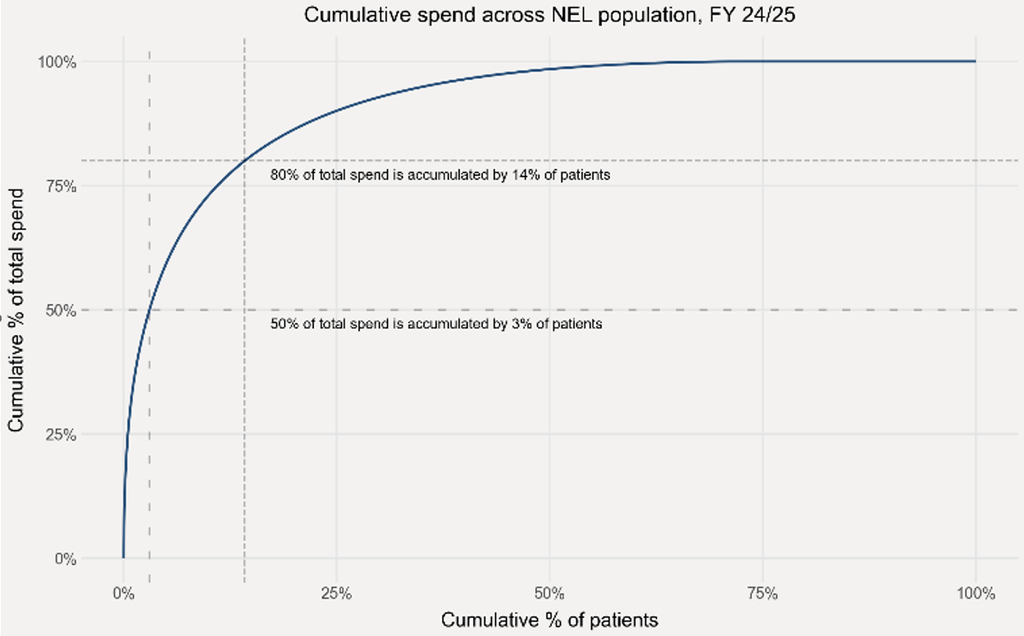

Cumulative spend across the NEL population

The prevalence of complexity in the very highest spend cohort reflects that a relatively small number of patients consume the largest proportion of health care spend. About 3% of our population consume 50% of the attributable health care spend. As with general spending patterns, patients with Serious Mental Health exhibit a spend burden in our services. Emphasising the importance of a targeted resource allocation approach that reflects health status and looking to prevent exacerbation of onset and exacerbation of long-term conditions.

## Demography

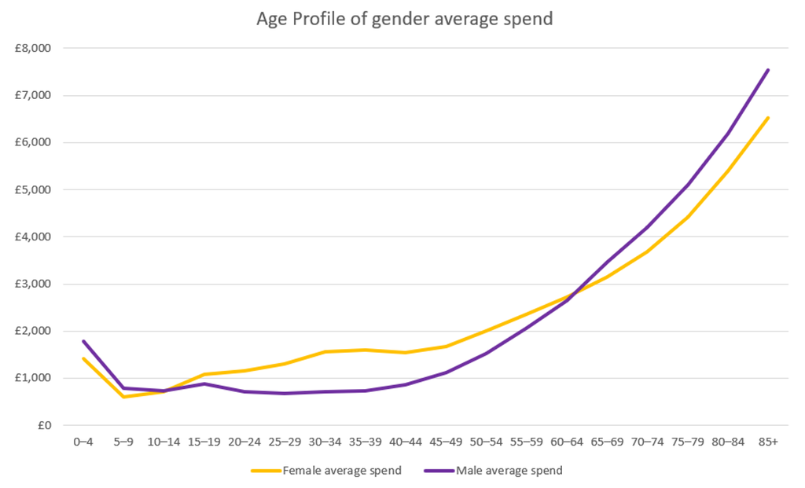

Age profile of spend by gender

To emphasise the influence of age, Havering our oldest borough with a mean average age of 39 has the highest spend per capita (£1,738) compared to Tower Hamlets (£1,327), our youngest borough with a mean age of 32. There are also gender differences: male spend exceeds female spend in infancy and older age bands (60-64+). However total female exceeds male expenditure across all care settings except for mental health admitted care.

[figure not shown]

Standardised spend across NEL Places and care settings

## Ethnicity

Ethnic disparities in spending reveal important insights for equity and access. British ethnicity (largest group) averages £2,196 per person versus £671 for Chinese patients. Caribbean and Other Black backgrounds have the highest spend per person across many care settings. Lower relative spend in some groups (Chinese, Indian, Any Other White) may reflect barriers to access, cultural factors, or unmet need. Concurrent analysis across age and ethnicity shows that these patterns persist through life courses, with some groups exhibiting 84% higher spend per head in working age relative to the average, whereas others show 61% lower spend, underscoring the need for culturally sensitive commissioning to meet diverse needs.

## Deprivation

Deprivation correlates with spend residents in the most deprived deciles generate around 12% more cost per person than those in the least deprived. While overall spend distribution across deciles broadly matches population share.

Two factors lessen the impact of deprivation in our data, firstly; unmet need may still exist in the most deprived communities and therefore not reflected in service utilisation and our spend analysis. Secondly, the influence of age on spend and proportion of our older adults in less deprived areas lessen and skews the gap between our most deprived utilisation and least deprived deprivation. Optimal resource allocation must therefore consider socio-economic gradients beyond observed spend patterns.

| Deprivation decile | Avg spend 0–17yr (£) | Avg spend 18–64yr (£) | Avg spend 65+yr (£) |
| --- | --- | --- | --- |
| **1 (most deprived)** | 1,007 | 1,632 | 4,896 |
| **2** | 1,083 | 1,486 | 4,992 |
| **3** | 1,027 | 1,332 | 4,628 |
| **4** | 974 | 1,353 | 4,379 |
| **5** | 1,002 | 1,308 | 4,387 |
| **6** | 960 | 1,164 | 4,167 |
| **7** | 877 | 1,166 | 3,934 |
| **8** | 839 | 1,080 | 3,864 |
| **9** | 859 | 1,138 | 3,782 |
| **10 (least deprived)** | 770 | 1,039 | 3,562 |
| **Unknown** | 564 | 895 | 5,447 |
| NEL average | 993 | 1,330 | 4,445 |

## Conclusion

Aligning resource allocation to population need across multiple dimensions (demography, ethnicity, deprivation, segmentation) can drive an improved and allocative efficiency, improve outcomes, and contribute to fairer commissioning decisions in the coming year and beyond. This emerging theme builds on the existing INA narrative and extends it into the crucial domain of financially informed planning.

A large data pack has been developed to support our early understanding of the drivers of spend. The initial analysis will be developed and evolve in response to the feedback and the strategic commissioning aimed at improving the allocative efficiency achieved through commissioning discussions. In the coming year this analysis will be refreshed with 25/56 data and include Drugs and Devices, Continuing Health Care, delegated Primary Care and other UEC settings of spend. A specific task to finish group will assess methodologies for applying a more refined approach to costing patient level data. In addition, another task to finish group will look to develop a robust understanding of ‘best value’ and align the spend analysis with outcomes. The analysis will also be enhanced by the strategic commissioning development programme which is rolled out.

## Footnotes

[^1]: Hypertension, when present as a stand-alone morbidity, was recommended for inclusion in the risk factors segment by the NEL Segmentation Advisory Group, 2025.
[^2]: Based on the national Census every 10 years, a lower super output area (LSOA) typically has a population between 1,000 and 3,000 people at Census time (~ 400 to 1,200 households). The boundary and size of an LSOA is determined by the geographic distribution of the population at census time. The total population in each can therefore change over the decade after a census depending on, for example, new housing developments.